# Is it music?

Pauline Larrouy-Maestri (Exp 1-3) & T. Ata Aydin (Exp 4)

### Experiment 1

Analysis of the Music data collected in September 2022

Following the preregistration: Larrouy-Maestri, P., & Wald-Fuhrmann, M. (2022, September 12). Definition of music: Effect of self- vs others-reference in the identification of auditory stimuli as music or not. Retrieved from osf.io/sb24q

Clear and load

```r
rm(list = ls())

# Load libraries
library(ggplot2)
library(GGally)
library(readxl)
library(dplyr)
library(lme4)
library(glm2)
library(ez)
library(stats)
library(lme4)
library(lmerTest)
library(corrplot)
library(ggcorrplot)
library(tidyverse)
library(hrbrthemes)
library(viridisLite)
library(viridis)
library(broom)
library(broom.mixed)
library(performance)
library(ordinal)
library(gridExtra)
library(Hmisc)
library(mclust)
library(NbClust)
library(ape)
library(vcd)
library(grid)

# Select data
Alldata <- read_excel("Exp_1.xlsx", sheet = "Reg_Analysis_1")
Selfdata <- subset(Alldata, Alldata$Condition == "self")
Otherdata <- subset(Alldata, Alldata$Condition == "other")
```

Rescale the Confidence ratings(0-3 instead of 1-4) to match the intention and the methods

```r
# Create a new column 'confidence_rescaled' that is a copy of 'Confidence'
Alldata$confidence_rescaled <- Alldata$Confidence

# Rescale 'confidence_rescaled' for all data
Alldata$confidence_rescaled<- Alldata$confidence_rescaled - 1
```

ANALYSIS 1: Effect of Condition (self versus other) on the categorisation of stimuli

Mixed effects logistic regression will be applied to predict the response (i.e., “Music” or “Not music”) from the condition, with random intercepts for participants and stimuli items.

NOTE that the syntax in the registration included the “a priori” condition but is not presented in the paper (only mentioned as a footnote) Proposed tentative syntax (in the registration): Music_answer ~ a priori group + Condition + a priori group:Condition + (1|Participant) + (1|Stim)

Code to change the baseline of the factors (self) for the model

```r
Alldata$Condition <- as.factor(Alldata$Condition)
Alldata$Condition <- relevel(Alldata$Condition, ref = "self")
```

Null and simplest model, including only Condition:

```r
Effect_null <- glmer(data = Alldata, Music_answer ~ 1 + (1|Participant) + (1|Stim), family = binomial)
summary(Effect_null)
```

```
## Generalized linear mixed model fit by maximum likelihood (Laplace
##   Approximation) [glmerMod]
##  Family: binomial  ( logit )
## Formula: Music_answer ~ 1 + (1 | Participant) + (1 | Stim)
##    Data: Alldata
##
##       AIC       BIC    logLik -2*log(L)  df.resid
##    8906.7    8930.1   -4450.4    8900.7     18081
##
## Scaled residuals:
##     Min      1Q  Median      3Q     Max
## -40.002  -0.179   0.030   0.159  16.533
##
## Random effects:
##  Groups      Name        Variance Std.Dev.
##  Participant (Intercept)  0.9493  0.9743
##  Stim        (Intercept) 18.6233  4.3155
## Number of obs: 18084, groups:  Participant, 202; Stim, 90
##
## Fixed effects:
##             Estimate Std. Error z value Pr(>|z|)
## (Intercept)   0.8645     0.4661   1.855   0.0636 .
## ---
## Signif. codes:  0 '***' 0.001 '**' 0.01 '*' 0.05 '.' 0.1 ' ' 1
```

```r
Effect_log <- glmer(data = Alldata, Music_answer ~ Condition + (1|Participant) + (1|Stim), family = binomial)
summary(Effect_log)
```

```
## Generalized linear mixed model fit by maximum likelihood (Laplace
##   Approximation) [glmerMod]
##  Family: binomial  ( logit )
## Formula: Music_answer ~ Condition + (1 | Participant) + (1 | Stim)
##    Data: Alldata
##
##       AIC       BIC    logLik -2*log(L)  df.resid
##    8903.1    8934.3   -4447.6    8895.1     18080
##
## Scaled residuals:
##     Min      1Q  Median      3Q     Max
## -39.331  -0.177   0.031   0.161  16.680
##
## Random effects:
##  Groups      Name        Variance Std.Dev.
##  Participant (Intercept)  0.9208  0.9596
##  Stim        (Intercept) 18.6715  4.3211
## Number of obs: 18084, groups:  Participant, 202; Stim, 90
##
## Fixed effects:
##                Estimate Std. Error z value Pr(>|z|)
## (Intercept)      1.0413     0.4722   2.205   0.0274 *
## Conditionother  -0.3488     0.1465  -2.380   0.0173 *
## ---
## Signif. codes:  0 '***' 0.001 '**' 0.01 '*' 0.05 '.' 0.1 ' ' 1
##
## Correlation of Fixed Effects:
##             (Intr)
## Conditinthr -0.154
```

```r
anova(Effect_null,Effect_log)
```

|  | npar | AIC | BIC | logLik | -2*log(L) | Chisq | Df | Pr(>Chisq) |
| --- | --- | --- | --- | --- | --- | --- | --- | --- |
| Effect_null | 3 | 8906.723 | 8930.132 | -4450.362 | 8900.723 | NA | NA | NA |
| Effect_log | 4 | 8903.136 | 8934.347 | -4447.568 | 8895.136 | 5.587846 | 1 | 0.01808552 |

Details about the full model

```r
tidy (Effect_log)
```

| effect | group | term | estimate | std.error | statistic | p.value |
| --- | --- | --- | --- | --- | --- | --- |
| fixed | NA | (Intercept) | 1.0413165 | 0.4721854 | 2.205313 | 0.02743216 |
| fixed | NA | Conditionother | -0.3488240 | 0.1465343 | -2.380495 | 0.01728940 |
| ran_pars | Participant | sd__(Intercept) | 0.9595669 | NA | NA | NA |
| ran_pars | Stim | sd__(Intercept) | 4.3210573 | NA | NA | NA |

```r
performance(Effect_log)
```

| AIC | AICc | BIC | R2_conditional | R2_marginal | ICC | RMSE | Sigma | Log_loss | Score_log | Score_spherical |
| --- | --- | --- | --- | --- | --- | --- | --- | --- | --- | --- |
| 8903.136 | 8903.138 | 8934.347 | 0.8564166 | 0.001327671 | 0.8562257 | 0.2566735 | 1 | 0.2169958 | -Inf | 0.0002284999 |

ICC for the random effects (all together and separately)

```r
# ICC calculation by group
icc_results_group <- performance::icc(Effect_log, by_group = TRUE)
print(icc_results_group)
```

```
## # ICC by Group
##
## Group       |   ICC
## -------------------
## Participant | 0.040
## Stim        | 0.816
```

```r
# ICC calculation for all random
icc_results_all <- performance::icc(Effect_log, by_group = FALSE)
print(icc_results_all)
```

```
## # Intraclass Correlation Coefficient
##
##     Adjusted ICC: 0.856
##   Unadjusted ICC: 0.855
```

ANALYSIS 1bis: Effect of condition (Condition: self versus other) on the confidence ratings (confidence as ordinal variable)

```r
conf_ord_r <- mutate(Alldata, confidence_rescaled = factor(confidence_rescaled, levels=0:3, ordered=TRUE))
conf_ord_r <- mutate(Alldata, Condition = factor(Condition, ordered=FALSE))

# Check the class and levels of the 'Confidence' variable
class(conf_ord_r$confidence_rescaled)
```

```
## [1] "numeric"
```

```r
levels(conf_ord_r$confidence_rescaled)
```

```r
# Convert 'Confidence' to factor if it's not already
conf_ord_r$confidence_rescaled <- factor(conf_ord_r$confidence_rescaled, ordered = TRUE)

# Check the class and levels again
class(conf_ord_r$confidence_rescaled)
```

```
## [1] "ordered" "factor"
```

```r
levels(conf_ord_r$confidence_rescaled)
```

```
## [1] "0" "1" "2" "3"
```

```r
# Fit the CLMM model without the effect of Condition
Effect_Conf_null_r <- clmm(confidence_rescaled ~ 1 + (1|Participant) + (1|Stim), data = conf_ord_r, link = "probit", threshold = "equidistant")
summary(Effect_Conf_null_r)
```

```
## Cumulative Link Mixed Model fitted with the Laplace approximation
##
## formula: confidence_rescaled ~ 1 + (1 | Participant) + (1 | Stim)
## data:    conf_ord_r
##
##  link   threshold   nobs  logLik    AIC      niter    max.grad cond.H
##  probit equidistant 18084 -14920.63 29849.26 196(996) 1.01e-03 8.1e+01
##
## Random effects:
##  Groups      Name        Variance Std.Dev.
##  Participant (Intercept) 0.2899   0.5384
##  Stim        (Intercept) 0.7301   0.8545
## Number of groups:  Participant 202,  Stim 90
##
## No Coefficients
##
## Threshold coefficients:
##             Estimate Std. Error z value
## threshold.1 -2.59734    0.10010  -25.95
## spacing      1.13614    0.01139   99.77
```

```r
# Fit the CLMM model with the effect of Condition
model_conf_ord_r <- clmm(confidence_rescaled ~ Condition + (1 | Participant) + (1 | Stim), data = conf_ord_r, link = "probit", threshold = "equidistant")
summary(model_conf_ord_r)
```

```
## Cumulative Link Mixed Model fitted with the Laplace approximation
##
## formula: confidence_rescaled ~ Condition + (1 | Participant) + (1 | Stim)
## data:    conf_ord_r
##
##  link   threshold   nobs  logLik    AIC      niter     max.grad cond.H
##  probit equidistant 18084 -14920.46 29850.92 277(1403) 2.89e-02 1.0e+02
##
## Random effects:
##  Groups      Name        Variance Std.Dev.
##  Participant (Intercept) 0.2894   0.5379
##  Stim        (Intercept) 0.7301   0.8544
## Number of groups:  Participant 202,  Stim 90
##
## Coefficients:
##                Estimate Std. Error z value Pr(>|z|)
## Conditionother -0.04595    0.07816  -0.588    0.557
##
## Threshold coefficients:
##             Estimate Std. Error z value
## threshold.1 -2.62030    0.10746  -24.38
## spacing      1.13614    0.01139   99.77
```

```r
# Comparison of the null and full model for confidence
anova(Effect_Conf_null_r,model_conf_ord_r)
```

|  | no.par | AIC | logLik | LR.stat | df | Pr(>Chisq) |
| --- | --- | --- | --- | --- | --- | --- |
| Effect_Conf_null_r | 4 | 29849.26 | -14920.63 | NA | NA | NA |
| model_conf_ord_r | 5 | 29850.92 | -14920.46 | 0.345352 | 1 | 0.5567561 |

```r
# ICC calculation by group (i.e., each random effects) for the NULL model (since the full model is not better)
icc_results_group <- performance::icc(Effect_Conf_null_r, by_group = TRUE)
print(icc_results_group)
```

```
## # ICC by Group
##
## Group       |   ICC
## -------------------
## Participant | 0.144
## Stim        | 0.361
```

```r
# ICC calculation for all random effects together for the NULL model (since the full model is not better)
icc_results_all <- performance::icc(Effect_Conf_null_r, by_group = FALSE)
print(icc_results_all)
```

```
## # Intraclass Correlation Coefficient
##
##     Adjusted ICC: 0.505
##   Unadjusted ICC: 0.505
```

### Figure 1A

```r
# Compute mean music responses and mean confidence ratings
DataPlot <- with(Alldata, aggregate(cbind(Music_answer, confidence_rescaled), list(Stimuli=Stim, Condition = Condition), mean))
DataPlot
```

| Stimuli | Condition | Music_answer | confidence_rescaled |
| --- | --- | --- | --- |
| M_apocalyptic_guitar.mp3 | self | 0.97029703 | 2.584158 |
| M_asian_flute.mp3 | self | 1.00000000 | 2.900990 |
| M_asian_guitar1.mp3 | self | 1.00000000 | 2.920792 |
| M_bahriyya.mp3 | self | 0.94059406 | 2.366337 |
| M_beats_experimental1.mp3 | self | 0.89108911 | 2.009901 |
| M_beats_experimental2.mp3 | self | 0.95049505 | 2.534653 |
| M_bells.mp3 | self | 1.00000000 | 2.712871 |
| M_bilal.mp3 | self | 0.97029703 | 2.356436 |
| M_blues_guitar1.mp3 | self | 1.00000000 | 2.900990 |
| M_blues_guitar3.mp3 | self | 1.00000000 | 2.950495 |

[output cut: 170 more lines]

Setting colors for the plots

```r
self = "orange"
other = "purple"

Condition_colors = c(self,other)
```

Plotting the music answers with 2 contrasted colors (Conditions: 1st and 3rd person, also names Self and Other conditions), with order according to the Self values

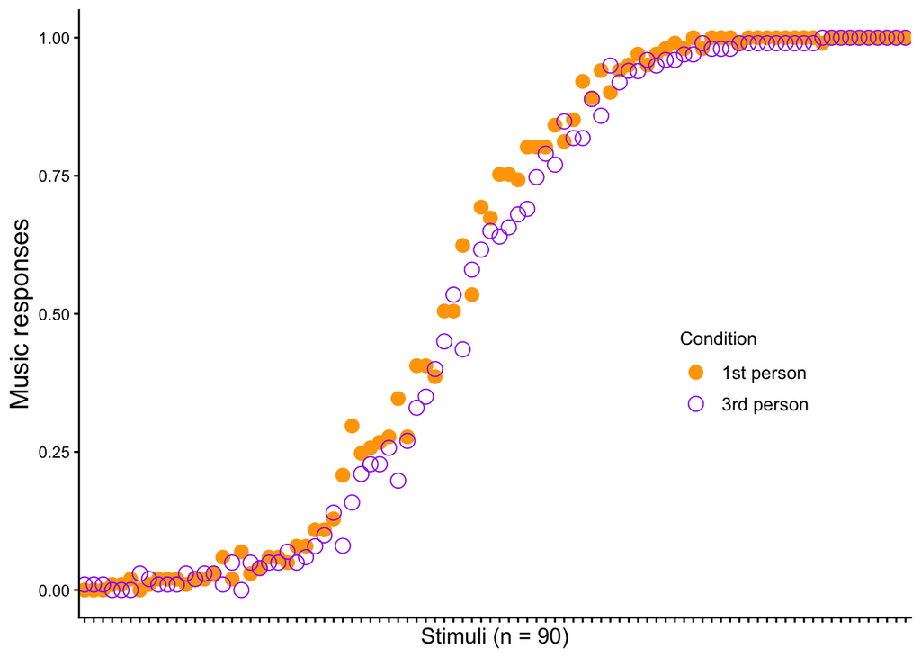

```r
# Calculate the mean Music_answer for each stimulus in the "self" condition
self_means <- with(subset(Alldata, Condition == "self"),
                   tapply(Music_answer, Stim, mean, na.rm = TRUE))

# Ensure the Music_answer column is numeric
DataPlot$Music_answer <- as.numeric(DataPlot$Music_answer)

# Reorder the Stimuli factor levels based on the means in the "self" condition
DataPlot$Stimuli <- factor(DataPlot$Stimuli,
                           levels = names(sort(self_means, decreasing = FALSE)))

# Reorder the levels of the Condition factor
DataPlot$Condition <- factor(DataPlot$Condition, levels = c("self", "other"))

ResponsePlot <- ggplot(DataPlot, aes(x = reorder(Stimuli, Music_answer), y = Music_answer, group = Condition, colour = Condition)) +
  geom_point(aes(shape = Condition), size = 3.5) +
  scale_colour_manual(values = Condition_colors,
                      labels = c("1st person", "3rd person")) +  # Rename Condition labels
  scale_shape_manual(values = c("self" = 16,   # Solid circle
                                "other" = 1),   # Hollow circle
                     labels = c("1st person", "3rd person")) +
  theme_classic() +
  xlab("Stimuli (n = 90)") +
  ylab("Music responses") +
  theme(axis.text.x = element_blank(),
        legend.text = element_text(size = 10),
        legend.title = element_text(size = 10),
        legend.position = c(0.8, 0.4),
        axis.title.y = element_text(size = 14),
        axis.title.x = element_text(size = 12),
        panel.background = element_rect(fill = "white"))  # Ensure white background

ResponsePlot
```

Plotting Confidence for self and other conditions

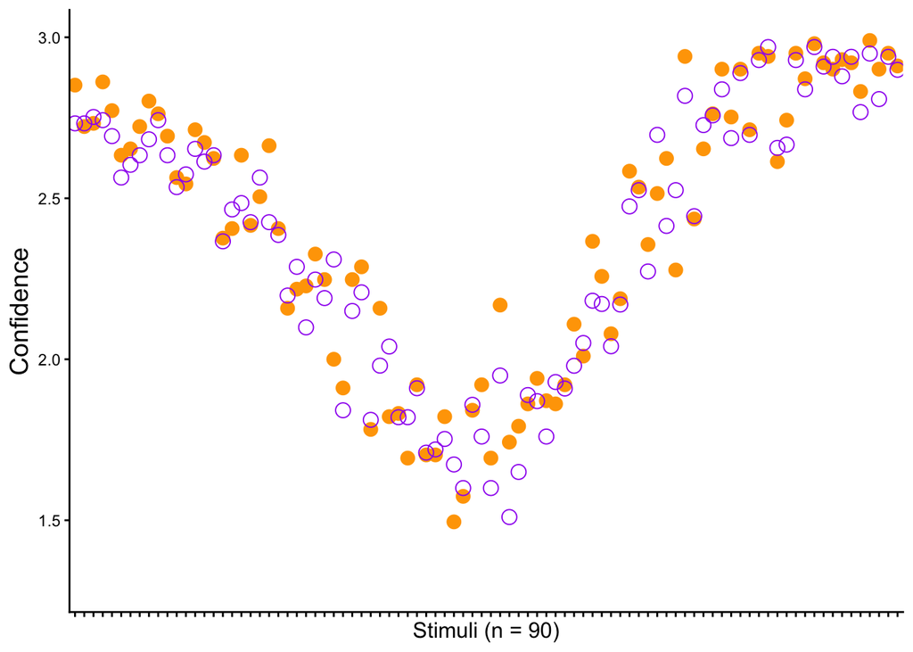

```r
# Reorder the Stimuli factor levels based on the means in the "self" condition
DataPlot$Stimuli <- factor(DataPlot$Stimuli,
                           levels = names(sort(self_means, decreasing = FALSE)))

# Reorder the levels of the Condition factor
DataPlot$Condition <- factor(DataPlot$Condition, levels = c("self", "other"))

ResponsePlot_conf <- ggplot(DataPlot, aes(x = reorder(Stimuli, Music_answer), y = confidence_rescaled, group = Condition, colour = Condition)) +
  geom_point(aes(shape = Condition), size = 3.5) +  # Adjust size for circles
  scale_colour_manual(values = Condition_colors,
                      labels = c("1st person", "3rd person")) +  # Rename Condition labels
  scale_shape_manual(values = c("self" = 16,   # Solid circle for "self"
                                "other" = 1),   # Hollow circle for "other"
                     labels = c("1st person", "3rd person")) +
  theme_classic() +
  xlab("Stimuli (n = 90)") +
  ylab("Confidence") +
  ylim(1.3, 3) +  # Adjust y-axis limits as needed
  theme(axis.text.x = element_blank(),
        legend.text = element_text(size = 12), # Change legend text font size
        legend.title = element_text(size = 12), # Change legend title font size
        legend.position = "none",  # Remove the legend
        axis.title.y = element_text(size = 14),
        axis.title.x = element_text(size = 12)) +
  theme(panel.background = element_rect(fill = "white"))

ResponsePlot_conf
```

Combine plots Identification/Confidence and save

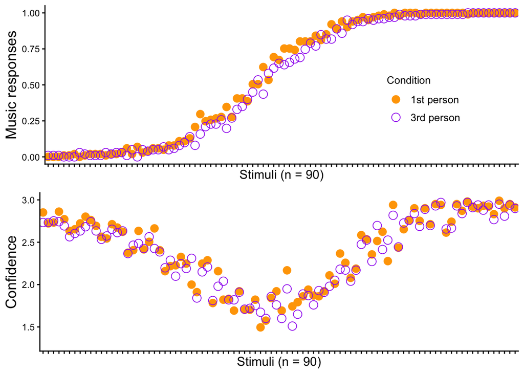

```r
Figure_1 <- grid.arrange(ResponsePlot,ResponsePlot_conf,ncol = 1)
```

```r
ggsave("~/Desktop/ResponsePlot_exp1.tiff", plot = Figure_1, width = 5, height = 5, dpi = 600, device = "tiff", compression = "lzw")
```

### Experiment 2

Analysis of the Music data collected in November 2022

Following the preregistration: Larrouy-Maestri, P., & Wald-Fuhrmann, M. (2022, November 21). Perception of sounds as music or not: effect of stimulus duration Retrieved from osf.io/azkcp

Clear and load

```r
rm(list = ls())

# Load data
Alldata <- read_excel("Exp_2.xlsx", sheet = "Categorisation_to_analyse")
data2<- subset(Alldata, Alldata$Duration == "2")
data5 <- subset(Alldata, Alldata$Duration == "5")
data10 <- subset(Alldata, Alldata$Duration == "10")

a_priori_exp1 <-as.numeric(Alldata$a_priori_exp1_label)
Duration <-as.factor(Alldata$Duration)
```

Rescale the Confidence ratings for duration short and long (0-3 instead of 1-4) to match the intention, the methods, and the date of the medium duration (i.e., data of Exp1, self)

```r
# Create a new column 'confidence_rescaled' that is a copy of 'confidence'
Alldata$confidence_rescaled <- Alldata$confidence

# Rescale 'confidence_rescaled' for Duration values 2 and 9
Alldata$confidence_rescaled[Alldata$Duration_label %in% c("short", "long")] <- Alldata$confidence_rescaled[Alldata$Duration_label %in% c("short", "long")] - 1

# Optional: Verify the changes
# You can check a subset of the data to ensure the changes are correct
head(Alldata[Alldata$Duration_label %in% c("short", "long"), c("Duration_label", "confidence", "confidence_rescaled")])
```

| Duration_label | confidence | confidence_rescaled |
| --- | --- | --- |
| long | 4 | 3 |
| long | 4 | 3 |
| long | 4 | 3 |
| long | 4 | 3 |
| long | 4 | 3 |
| long | 4 | 3 |

ANALYSIS 1: Effect of duration (2 versus 5 versus 10) on the categorisation of stimuli

Mixed effects logistic regression will be applied to predict the response (i.e., “Music” or “Not music”) from the condition (i.e., duration: 2, 5, 10 seconds), with random intercepts for participants and stimuli items.

NOTE that we don’t use the results of Exp1 (3 groups:music, no_music, ambiguous) since we reuse the data of the “self” group from which the three groups were defined

NOTE that the syntax in the registration included the “a priori” condition but is not presented in the paper (only mentioned as a footnote) Proposed tentative syntax (in the registration): Music_answer ~ a priori group + Duration + a priori group:Duration + (1|exp_subject_id) + (1|stim_name)

Code to change the baseline of the factors (Duration_label) for the model

```r
Alldata$Duration_label <- as.factor(Alldata$Duration_label)
Alldata$Duration_label <- relevel(Alldata$Duration_label, ref = "medium")
```

Null and simplest model, including only duration:

```r
Effect_null <- glmer(data = Alldata, Music_answer ~ 1 + (1|exp_subject_id) + (1|stim_name), family = binomial)
summary(Effect_null)
```

```
## Generalized linear mixed model fit by maximum likelihood (Laplace
##   Approximation) [glmerMod]
##  Family: binomial  ( logit )
## Formula: Music_answer ~ 1 + (1 | exp_subject_id) + (1 | stim_name)
##    Data: Alldata
##
##       AIC       BIC    logLik -2*log(L)  df.resid
##     11002     11026     -5498     10996     22347
##
## Scaled residuals:
##      Min       1Q   Median       3Q      Max
## -18.4936  -0.1994   0.0281   0.1433  19.6758
##
## Random effects:
##  Groups         Name        Variance Std.Dev.
##  exp_subject_id (Intercept)  0.9988  0.9994
##  stim_name      (Intercept) 20.2061  4.4951
## Number of obs: 22350, groups:  exp_subject_id, 298; stim_name, 75
##
## Fixed effects:
##             Estimate Std. Error z value Pr(>|z|)
## (Intercept)   1.6566     0.5301   3.125  0.00178 **
## ---
## Signif. codes:  0 '***' 0.001 '**' 0.01 '*' 0.05 '.' 0.1 ' ' 1
```

```r
Effect_log <- glmer(data = Alldata, Music_answer ~ Duration_label + (1|exp_subject_id) + (1|stim_name), family = binomial)
summary(Effect_log)
```

```
## Generalized linear mixed model fit by maximum likelihood (Laplace
##   Approximation) [glmerMod]
##  Family: binomial  ( logit )
## Formula: Music_answer ~ Duration_label + (1 | exp_subject_id) + (1 | stim_name)
##    Data: Alldata
##
##       AIC       BIC    logLik -2*log(L)  df.resid
##   10993.3   11033.3   -5491.6   10983.3     22345
##
## Scaled residuals:
##      Min       1Q   Median       3Q      Max
## -18.1067  -0.1984   0.0287   0.1436  20.0522
##
## Random effects:
##  Groups         Name        Variance Std.Dev.
##  exp_subject_id (Intercept)  0.9486  0.9739
##  stim_name      (Intercept) 20.1970  4.4941
## Number of obs: 22350, groups:  exp_subject_id, 298; stim_name, 75
##
## Fixed effects:
##                     Estimate Std. Error z value Pr(>|z|)
## (Intercept)           1.9430     0.5368   3.620 0.000295 ***
## Duration_labellong   -0.3282     0.1511  -2.172 0.029854 *
## Duration_labelshort  -0.5396     0.1509  -3.575 0.000350 ***
## ---
## Signif. codes:  0 '***' 0.001 '**' 0.01 '*' 0.05 '.' 0.1 ' ' 1
##
## Correlation of Fixed Effects:
##             (Intr) Drtn_lbll
## Drtn_lbllng -0.139
## Drtn_lblshr -0.139  0.493
```

```r
anova(Effect_null,Effect_log)
```

|  | npar | AIC | BIC | logLik | -2*log(L) | Chisq | Df | Pr(>Chisq) |
| --- | --- | --- | --- | --- | --- | --- | --- | --- |
| Effect_null | 3 | 11001.97 | 11026.01 | -5497.983 | 10995.97 | NA | NA | NA |
| Effect_log | 5 | 10993.27 | 11033.34 | -5491.635 | 10983.27 | 12.69665 | 2 | 0.001749673 |

Details about the full model

```r
tidy (Effect_log)
```

| effect | group | term | estimate | std.error | statistic | p.value |
| --- | --- | --- | --- | --- | --- | --- |
| fixed | NA | (Intercept) | 1.9429876 | 0.5368105 | 3.619504 | 0.0002951686 |
| fixed | NA | Duration_labellong | -0.3282279 | 0.1511160 | -2.172026 | 0.0298537086 |
| fixed | NA | Duration_labelshort | -0.5395515 | 0.1509244 | -3.574978 | 0.0003502572 |
| ran_pars | exp_subject_id | sd__(Intercept) | 0.9739500 | NA | NA | NA |
| ran_pars | stim_name | sd__(Intercept) | 4.4941050 | NA | NA | NA |

```r
performance(Effect_log)
```

| AIC | AICc | BIC | R2_conditional | R2_marginal | ICC | RMSE | Sigma | Log_loss | Score_log | Score_spherical |
| --- | --- | --- | --- | --- | --- | --- | --- | --- | --- | --- |
| 10993.27 | 10993.27 | 11033.34 | 0.8656379 | 0.002028482 | 0.8653648 | 0.259463 | 1 | 0.2186204 | -Inf | 6.643692e-05 |

ICC for the random effects (all together and separately)

```r
# ICC calculation by group
icc_results_group <- performance::icc(Effect_log, by_group = TRUE)
print(icc_results_group)
```

```
## # ICC by Group
##
## Group          |   ICC
## ----------------------
## exp_subject_id | 0.039
## stim_name      | 0.827
```

```r
# ICC calculation for all random
icc_results_all <- performance::icc(Effect_log, by_group = FALSE)
print(icc_results_all)
```

```
## # Intraclass Correlation Coefficient
##
##     Adjusted ICC: 0.865
##   Unadjusted ICC: 0.864
```

ANALYSIS 1bis: Effect of condition (duration: short, medium, long) on the confidence ratings (confidence as ordinal variable)

```r
conf_ord_r <- mutate(Alldata, confidence_rescaled = factor(confidence_rescaled, levels=0:3, ordered=TRUE))
conf_ord_r <- mutate(Alldata, Condition = factor(Duration_label, ordered=FALSE))

# Check the class and levels of the 'Confidence' variable
class(conf_ord_r$confidence_rescaled)
```

```
## [1] "numeric"
```

```r
levels(conf_ord_r$confidence_rescaled)
```

```r
# Convert 'Confidence' to factor if it's not already
conf_ord_r$confidence_rescaled <- factor(conf_ord_r$confidence_rescaled, ordered = TRUE)

# Check the class and levels again
class(conf_ord_r$confidence_rescaled)
```

```
## [1] "ordered" "factor"
```

```r
levels(conf_ord_r$confidence_rescaled)
```

```
## [1] "0" "1" "2" "3"
```

```r
# Fit the CLMM model without the effect of Condition
Effect_Conf_null_r <- clmm(confidence_rescaled ~ 1 + (1|exp_subject_id) + (1|stim_name), data = conf_ord_r, link = "probit", threshold = "equidistant")
summary(Effect_Conf_null_r)
```

```
## Cumulative Link Mixed Model fitted with the Laplace approximation
##
## formula: confidence_rescaled ~ 1 + (1 | exp_subject_id) + (1 | stim_name)
## data:    conf_ord_r
##
##  link   threshold   nobs  logLik    AIC      niter     max.grad cond.H
##  probit equidistant 22350 -18572.98 37153.96 223(1131) 2.40e-03 1.2e+02
##
## Random effects:
##  Groups         Name        Variance Std.Dev.
##  exp_subject_id (Intercept) 0.3114   0.558
##  stim_name      (Intercept) 0.7465   0.864
## Number of groups:  exp_subject_id 298,  stim_name 75
##
## No Coefficients
##
## Threshold coefficients:
##             Estimate Std. Error z value
## threshold.1 -2.56205    0.10664  -24.02
## spacing      1.11763    0.01006  111.13
```

```r
# Fit the CLMM model with the effect of Condition
model_conf_ord_r <- clmm(confidence_rescaled ~ Duration_label + (1 | exp_subject_id) + (1 | stim_name), data = conf_ord_r, link = "probit", threshold = "equidistant")
summary(model_conf_ord_r)
```

```
## Cumulative Link Mixed Model fitted with the Laplace approximation
##
## formula: confidence_rescaled ~ Duration_label + (1 | exp_subject_id) +
##     (1 | stim_name)
## data:    conf_ord_r
##
##  link   threshold   nobs  logLik    AIC      niter     max.grad cond.H
##  probit equidistant 22350 -18572.59 37157.17 371(1875) 2.51e-02 1.7e+02
##
## Random effects:
##  Groups         Name        Variance Std.Dev.
##  exp_subject_id (Intercept) 0.3104   0.5572
##  stim_name      (Intercept) 0.7465   0.8640
## Number of groups:  exp_subject_id 298,  stim_name 75
##
## Coefficients:
##                     Estimate Std. Error z value Pr(>|z|)
## Duration_labellong   0.01056    0.08187   0.129    0.897
## Duration_labelshort -0.05704    0.08164  -0.699    0.485
##
## Threshold coefficients:
##             Estimate Std. Error z value
## threshold.1 -2.57749    0.11639  -22.14
## spacing      1.11763    0.01006  111.13
```

```r
# Comparison of the null and full model for confidence
anova(Effect_Conf_null_r,model_conf_ord_r)
```

|  | no.par | AIC | logLik | LR.stat | df | Pr(>Chisq) |
| --- | --- | --- | --- | --- | --- | --- |
| Effect_Conf_null_r | 4 | 37153.96 | -18572.98 | NA | NA | NA |
| model_conf_ord_r | 6 | 37157.17 | -18572.59 | 0.784391 | 2 | 0.675572 |

```r
# ICC calculation by group (i.e., each random effects) for the NULL model (since the full model is not better)
icc_results_group <- performance::icc(Effect_Conf_null_r, by_group = TRUE)
print(icc_results_group)
```

```
## # ICC by Group
##
## Group          |   ICC
## ----------------------
## exp_subject_id | 0.151
## stim_name      | 0.363
```

```r
# ICC calculation for all random effects together for the NULL model (since the full model is not better)
icc_results_all <- performance::icc(Effect_Conf_null_r, by_group = FALSE)
print(icc_results_all)
```

```
## # Intraclass Correlation Coefficient
##
##     Adjusted ICC: 0.514
##   Unadjusted ICC: 0.514
```

### Figure 1B

```r
# Compute mean music responses and mean confidence ratings
DataPlot <- with(Alldata, aggregate(Music_answer, list(Stimuli=stim_name,Condition=Duration_label), mean))
```

Setting colors for the plots

```r
s = "gold"
m = "orange"
l = "brown"

dur_colors = c(s,m,l)
```

Plotting the music answers with 3 colors (Conditions: Short, Medium, and Long stimuli)

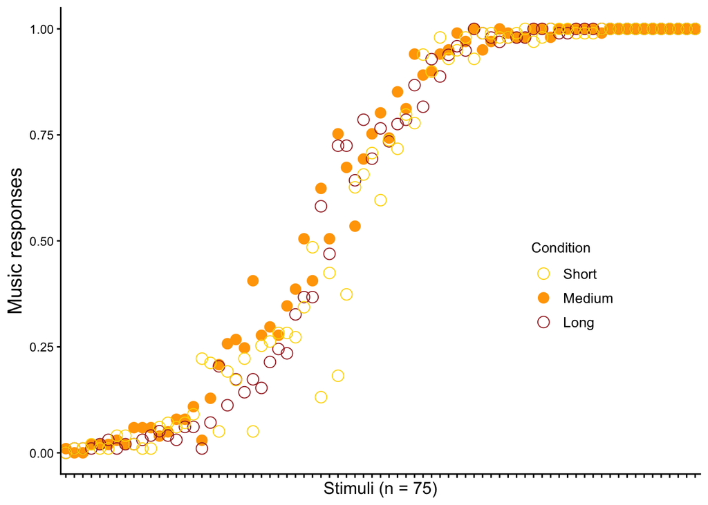

```r
DataPlot <- with(Alldata, aggregate(Music_answer, list(Stimuli=stim_name,Condition=Duration_label), mean))

# Reorder the levels of the Condition factor
DataPlot$Condition <- factor(DataPlot$Condition, levels = c("short", "medium", "long"))

# Create the plot with the reordered Condition levels
ResponsePlot <- ggplot(DataPlot, aes(x = reorder(Stimuli, x), y = x, group = Condition, colour = Condition)) +
  geom_point(aes(shape = Condition), size = 3.5) +
  scale_colour_manual(values = dur_colors,
                      labels = c("Short", "Medium", "Long")) +
  scale_shape_manual(values = c("short" = 1,   # Solid circle
                                 "medium" = 16,
                                 "long"= 1),   # Hollow circle
                     labels = c("Short", "Medium", "Long")) +
  theme_classic() +
  xlab("Stimuli (n = 75)") +
  ylab("Music responses") +
  theme(axis.text.x = element_blank(),
        legend.text = element_text(size = 10),
        legend.title = element_text(size = 10),
        legend.position = c(0.8, 0.4),
        axis.title.y = element_text(size = 14),
        axis.title.x = element_text(size = 12)) +
  theme(panel.background = element_rect(fill = "white"))

ResponsePlot
```

Plotting Confidence for Short, Medium, and Long stimuli

```r
# Compute mean music responses and mean confidence ratings
DataPlot <- with(Alldata, aggregate(cbind(Music_answer, confidence_rescaled), list(Stimuli=stim_name, Condition = Duration_label), mean))
DataPlot
```

| Stimuli | Condition | Music_answer | confidence_rescaled |
| --- | --- | --- | --- |
| M_apocalyptic_guitar | medium | 0.97029703 | 2.584158 |
| M_asian_flute | medium | 1.00000000 | 2.900990 |
| M_asian_guitar | medium | 1.00000000 | 2.920792 |
| M_bahriyya | medium | 0.94059406 | 2.366337 |
| M_beats_experimental | medium | 0.89108911 | 2.009901 |
| M_beats_experimental2 | medium | 0.95049505 | 2.534653 |
| M_bells | medium | 1.00000000 | 2.712871 |
| M_bilal | medium | 0.97029703 | 2.356436 |
| M_blues_guitar1 | medium | 1.00000000 | 2.900990 |
| M_blues_guitar3 | medium | 1.00000000 | 2.950495 |

[output cut: 215 more lines]

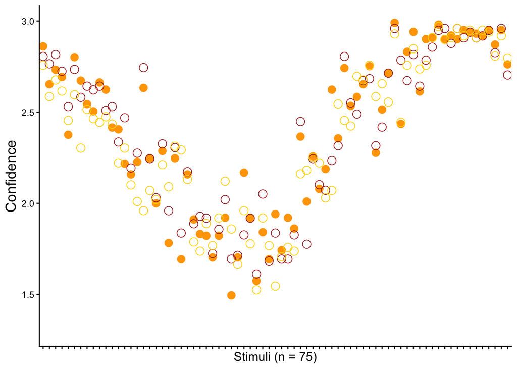

```r
# Reorder the levels of the Condition factor
DataPlot$Condition <- factor(DataPlot$Condition, levels = c("short", "medium", "long"))

# Plot confidence like for identification
ResponsePlot_conf <- ggplot(DataPlot, aes(x = reorder(Stimuli, Music_answer), y = confidence_rescaled, group = Condition, colour = Condition)) +
  geom_point(aes(shape = Condition), size = 3.5) +
  scale_colour_manual(values = dur_colors,
                      labels = c("Short", "Medium", "Long")) +
  scale_shape_manual(values = c("short" = 1,   # Hollow circle
                                 "medium" = 16, # Solid circle
                                 "long"= 1),   # Hollow circle
                     labels = c("Short", "Medium", "Long")) +
  theme_classic() +
  # scale_shape(solid = FALSE) +
  xlab("Stimuli (n = 75)") +
  ylab("Confidence") +
  ylim(1.3, 3) +  # Adjust y-axis limits as needed
  theme(axis.text.x = element_blank(),
        legend.text = element_text(size = 12), # Change legend text font size
        legend.title = element_text(size = 12), # Change legend title font size
        legend.position = "none",  # Remove the legend
        axis.title.y = element_text(size = 14),
        axis.title.x = element_text(size = 12)) +
  theme(panel.background = element_rect(fill = "white"))

ResponsePlot_conf
```

Combine plots and save

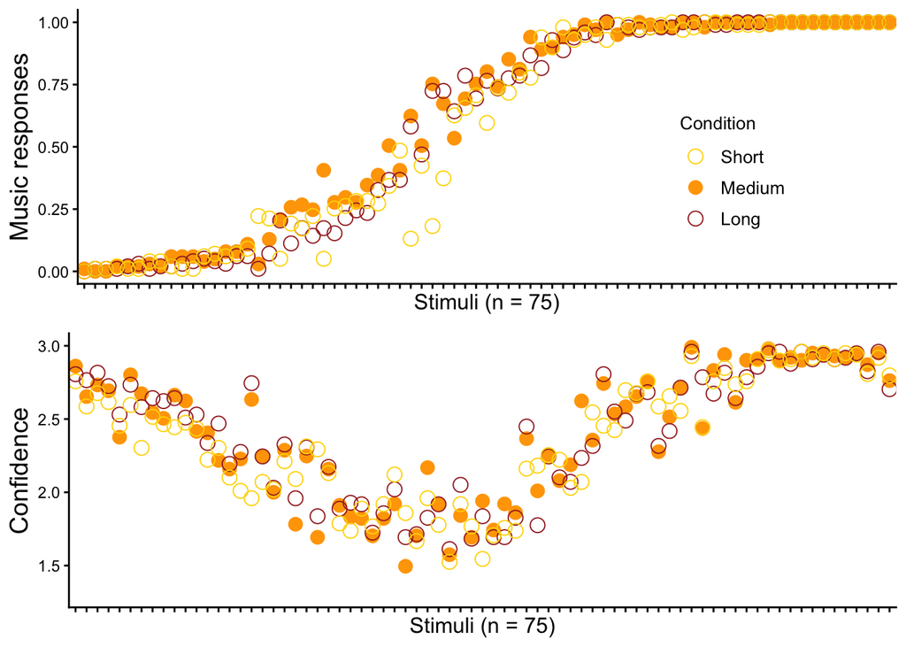

```r
Figure_1B <- grid.arrange(ResponsePlot,ResponsePlot_conf,ncol = 1)
```

```r
ggsave("~/Desktop/ResponsePlot_exp2.tiff", plot = Figure_1B, width = 4, height = 5, dpi = 600, device = "tiff", compression = "lzw")
```

### Experiment 3

Analysis of the Music data collected in November 2022

Following the preregistration: Larrouy-Maestri, P., & Wald-Fuhrmann, M. (2022, November 21). Perception of sounds as music or not: effect of stimulus duration Retrieved from osf.io/azkcp

Clear and load

```r
rm(list = ls())

# Load data
Alldata <- read_excel("Exp_3.xlsx", sheet = "Categorisation_to_analyse")

Stimulus <- as.numeric(Alldata$stim_name)
exp_subject_id <-as.factor(Alldata$exp_subject_id)
```

ANALYSIS 1: Effect of repetition on the categorisation of stimuli

Mixed effects logistic regression will be applied to predict the response (i.e., “Music” or “Not music”) from the condition (i.e., first or second presentation), with random intercepts for participants and stimuli items.

NOTE that the syntax in the registration included the “a priori” condition but is not presented in the paper (only mentioned as a footnote) Proposed tentative syntax (in the registration): Music_answer ~ a priori group + Order + a priori group:Order + (1|exp_subject_id) + (1|stim_name)

Code to change the baseline of the factors (Order_letter) for the model

```r
Alldata$Order_letter <- as.factor(Alldata$Order_letter)
Alldata$Order_letter <- relevel(Alldata$Order_letter, ref = "test")
```

```r
Effect_null <- glmer(data = Alldata, Music_answer ~ 1 + (1|exp_subject_id) + (1|stim_name), family = binomial)
summary(Effect_null)
```

```
## Generalized linear mixed model fit by maximum likelihood (Laplace
##   Approximation) [glmerMod]
##  Family: binomial  ( logit )
## Formula: Music_answer ~ 1 + (1 | exp_subject_id) + (1 | stim_name)
##    Data: Alldata
##
##       AIC       BIC    logLik -2*log(L)  df.resid
##   11160.6   11184.4   -5577.3   11154.6     20157
##
## Scaled residuals:
##      Min       1Q   Median       3Q      Max
## -15.2054  -0.2813  -0.0531   0.1321  20.0969
##
## Random effects:
##  Groups         Name        Variance Std.Dev.
##  exp_subject_id (Intercept)  1.93    1.389
##  stim_name      (Intercept) 14.75    3.841
## Number of obs: 20160, groups:  exp_subject_id, 240; stim_name, 42
##
## Fixed effects:
##             Estimate Std. Error z value Pr(>|z|)
## (Intercept)  -0.6018     0.6017      -1    0.317
```

```r
Effect_log <- glmer(data = Alldata, Music_answer ~ Order_letter + (1|exp_subject_id) + (1|stim_name), family = binomial)
summary(Effect_log)
```

```
## Generalized linear mixed model fit by maximum likelihood (Laplace
##   Approximation) [glmerMod]
##  Family: binomial  ( logit )
## Formula: Music_answer ~ Order_letter + (1 | exp_subject_id) + (1 | stim_name)
##    Data: Alldata
##
##       AIC       BIC    logLik -2*log(L)  df.resid
##   11158.7   11190.3   -5575.3   11150.7     20156
##
## Scaled residuals:
##      Min       1Q   Median       3Q      Max
## -15.6036  -0.2817  -0.0522   0.1324  20.6263
##
## Random effects:
##  Groups         Name        Variance Std.Dev.
##  exp_subject_id (Intercept)  1.932   1.390
##  stim_name      (Intercept) 14.761   3.842
## Number of obs: 20160, groups:  exp_subject_id, 240; stim_name, 42
##
## Fixed effects:
##                    Estimate Std. Error z value Pr(>|z|)
## (Intercept)        -0.55223    0.60242  -0.917   0.3593
## Order_letterretest -0.09978    0.04970  -2.008   0.0447 *
## ---
## Signif. codes:  0 '***' 0.001 '**' 0.01 '*' 0.05 '.' 0.1 ' ' 1
##
## Correlation of Fixed Effects:
##             (Intr)
## Ordr_lttrrt -0.041
```

```r
anova(Effect_null,Effect_log)
```

|  | npar | AIC | BIC | logLik | -2*log(L) | Chisq | Df | Pr(>Chisq) |
| --- | --- | --- | --- | --- | --- | --- | --- | --- |
| Effect_null | 3 | 11160.62 | 11184.36 | -5577.311 | 11154.62 | NA | NA | NA |
| Effect_log | 4 | 11158.68 | 11190.33 | -5575.340 | 11150.68 | 3.942866 | 1 | 0.04707052 |

Details about the full model

```r
tidy (Effect_log)
```

| effect | group | term | estimate | std.error | statistic | p.value |
| --- | --- | --- | --- | --- | --- | --- |
| fixed | NA | (Intercept) | -0.55222931 | 0.60242428 | -0.9166784 | 0.35931120 |
| fixed | NA | Order_letterretest | -0.09977665 | 0.04969851 | -2.0076389 | 0.04468168 |
| ran_pars | exp_subject_id | sd__(Intercept) | 1.38991186 | NA | NA | NA |
| ran_pars | stim_name | sd__(Intercept) | 3.84197770 | NA | NA | NA |

```r
performance(Effect_log)
```

| AIC | AICc | BIC | R2_conditional | R2_marginal | ICC | RMSE | Sigma | Log_loss | Score_log | Score_spherical |
| --- | --- | --- | --- | --- | --- | --- | --- | --- | --- | --- |
| 11158.68 | 11158.68 | 11190.33 | 0.8353832 | 0.0001245418 | 0.8353627 | 0.2767906 | 1 | 0.2487866 | -Inf | 0.0005846583 |

ICC for the random effects (all together and separately)

```r
# ICC calculation by group
icc_results_group <- performance::icc(Effect_log, by_group = TRUE)
print(icc_results_group)
```

```
## # ICC by Group
##
## Group          |   ICC
## ----------------------
## exp_subject_id | 0.097
## stim_name      | 0.739
```

```r
# ICC calculation for all random
icc_results_all <- performance::icc(Effect_log, by_group = FALSE)
print(icc_results_all)
```

```
## # Intraclass Correlation Coefficient
##
##     Adjusted ICC: 0.835
##   Unadjusted ICC: 0.835
```

# Figure 1C

Preparation for the figure with each retests (3 conditions) against the baseline (single for all “test”)

```r
Alldata <- Alldata %>%
  mutate(New_Group = case_when(
    Order_letter == 'test'  ~ 'Baseline',
    Order_letter == 'retest' & Position == 'BB' ~ 'BB',
    Order_letter == 'retest' & Position == 'WBR' ~ 'WBR',
    Order_letter == 'retest' & Position == 'WBC' ~ 'WBC',
    TRUE ~ 'Other'
  ))
```

Setting colors for the plots

```r
baseline = "grey"
BB = "pink"
WBR = "cyan"
WBC = "magenta"

Position_colors = c(baseline,BB,WBR,WBC)
```

```r
## From exp2:
  # Compute mean music responses and mean confidence ratings
DataPlot <- with(Alldata, aggregate(Music_answer, list(Stimuli=stim_name,Condition=New_Group), mean))

DataPlot
```

| Stimuli | Condition | x |
| --- | --- | --- |
| M_beats_experimental1 | Baseline | 0.866666667 |
| M_bells | Baseline | 0.983333333 |
| M_caballo_blanco | Baseline | 0.737500000 |
| M_cana_verde | Baseline | 0.987500000 |
| M_dundun6M | Baseline | 0.875000000 |
| M_experimental01 | Baseline | 0.125000000 |
| M_experimental04 | Baseline | 0.200000000 |
| M_experimental05 | Baseline | 0.804166667 |
| M_experimental11 | Baseline | 0.208333333 |
| M_experimental17 | Baseline | 0.541666667 |

[output cut: 158 more lines]

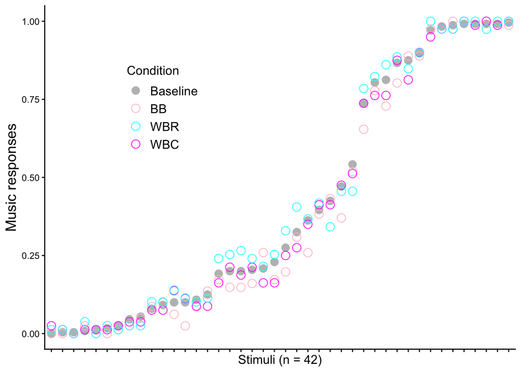

```r
Baseline_means <- with(subset(Alldata, New_Group == "Baseline"),
                   tapply(Music_answer, stim_name, mean, na.rm = TRUE))

# Reorder the Stimuli factor levels based on the means in the "self" condition
DataPlot$Stimuli <- factor(DataPlot$Stimuli,
                           levels = names(sort(Baseline_means, decreasing = FALSE)))

# Reorder the levels of the Condition factor
DataPlot$Condition <- factor(DataPlot$Condition, levels = c("Baseline", "BB", "WBR","WBC"))


# Create the plot with the reordered Condition levels
ResponsePlot <- ggplot(DataPlot, aes(Stimuli, y = x, group = Condition, colour = Condition)) +
  geom_point(aes(shape = Condition), size = 3.5) +
  scale_colour_manual(values = Position_colors,
                      labels = c("Baseline",  "BB", "WBR","WBC")) +
  scale_shape_manual(values = c("Baseline" = 16,   # Solid circle
                                 "BB" = 1,
                                 "WBR"= 1,
                                 "WBC"= 1),   # Hollow circle
                     labels = c("Baseline",  "BB", "WBR","WBC")) +
  theme_classic() +
  xlab("Stimuli (n = 42)") +
  ylab("Music responses") +
  theme(axis.text.x = element_blank(),
        legend.text = element_text(size = 12),
        legend.title = element_text(size = 12),
        legend.position = c(0.25, 0.7),  # Move legend to top-left
        axis.title.y = element_text(size = 14),
        axis.title.x = element_text(size = 12),
        legend.spacing.y = unit(0.1, "cm")) +  # Adjust space between legend items
  theme(panel.background = element_rect(fill = "white"))
ResponsePlot
```

Create and export plot

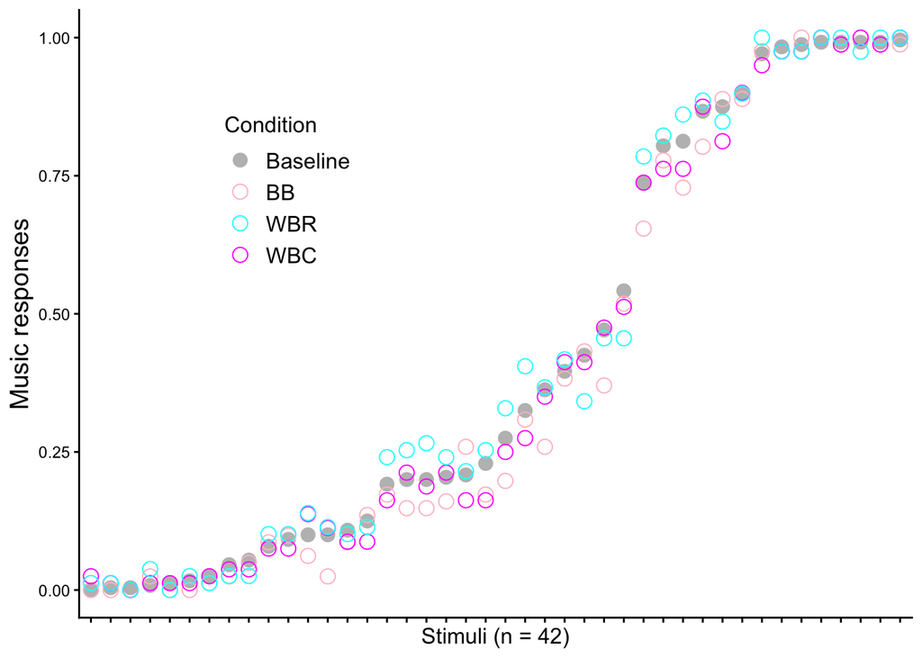

```r
Figure_1C <- grid.arrange(ResponsePlot,ncol = 1)
```

```r
ggsave("~/Desktop/ResponsePlot_exp3a.tiff", plot = Figure_1C, width = 3, height = 2, dpi = 600, device = "tiff", compression = "lzw")
```

Listeners’ consistence observed with test-retest phi-coefficients for each condition

```r
consist_sub <- with(Alldata, aggregate(Music_answer, list(Sub=exp_subject_id, Stimuli=stim_name,Position=Position,Repetition=Order), mean))
consist_sub
```

| Sub | Stimuli | Position | Repetition | x |
| --- | --- | --- | --- | --- |
| 599681 | M_beats_experimental1 | BB | 1 | 1 |
| 599682 | M_beats_experimental1 | BB | 1 | 1 |
| 599683 | M_beats_experimental1 | BB | 1 | 1 |
| 599685 | M_beats_experimental1 | BB | 1 | 1 |
| 599686 | M_beats_experimental1 | BB | 1 | 1 |
| 599687 | M_beats_experimental1 | BB | 1 | 1 |
| 599689 | M_beats_experimental1 | BB | 1 | 0 |
| 599690 | M_beats_experimental1 | BB | 1 | 1 |
| 599692 | M_beats_experimental1 | BB | 1 | 0 |
| 599693 | M_beats_experimental1 | BB | 1 | 1 |

[output cut: 9990 more lines]

```r
consistency_sub <-reshape(consist_sub, idvar =c("Stimuli", "Position","Sub"), timevar = c("Repetition"), direction = "wide")
consistency_sub
```

|  | Sub | Stimuli | Position | x.1 | x.2 |
| --- | --- | --- | --- | --- | --- |
| 1 | 599681 | M_beats_experimental1 | BB | 1 | 1 |
| 2 | 599682 | M_beats_experimental1 | BB | 1 | 1 |
| 3 | 599683 | M_beats_experimental1 | BB | 1 | 1 |
| 4 | 599685 | M_beats_experimental1 | BB | 1 | 1 |
| 5 | 599686 | M_beats_experimental1 | BB | 1 | 0 |
| 6 | 599687 | M_beats_experimental1 | BB | 1 | 1 |
| 7 | 599689 | M_beats_experimental1 | BB | 0 | 0 |
| 8 | 599690 | M_beats_experimental1 | BB | 1 | 1 |
| 9 | 599692 | M_beats_experimental1 | BB | 0 | 0 |
| 10 | 599693 | M_beats_experimental1 | BB | 1 | 0 |

[output cut: 9990 more lines]

```r
sub_correlation <- consistency_sub %>%
  group_by(Sub, Position) %>%
  summarise(
    phi_coefficient = {
      tbl <- table(x.1, x.2)
      assocstats(tbl)$phi
    },
    p_value = {
      tbl <- table(x.1, x.2)
      chisq.test(tbl)$p.value
    }
  )
```

[output not shown]

```r
print(sub_correlation)
```

```
## # A tibble: 240 × 4
## # Groups:   Sub [240]
##       Sub Position phi_coefficient  p_value
##     <dbl> <chr>              <dbl>    <dbl>
##  1 599681 BB                 0.851 2.06e- 7
##  2 599682 BB                 1     7.57e-10
##  3 599683 BB                 0.945 8.80e- 9
##  4 599685 BB                 0.857 1.55e- 7
##  5 599686 BB                 0.890 7.19e- 8
##  6 599687 BB                 0.906 2.87e- 8
##  7 599689 BB                 0.938 1.43e- 8
##  8 599690 BB                 0.807 9.23e- 7
##  9 599692 BB                 0.831 5.34e- 7
## 10 599693 BB                 0.812 8.57e- 7
## # ℹ 230 more rows
```

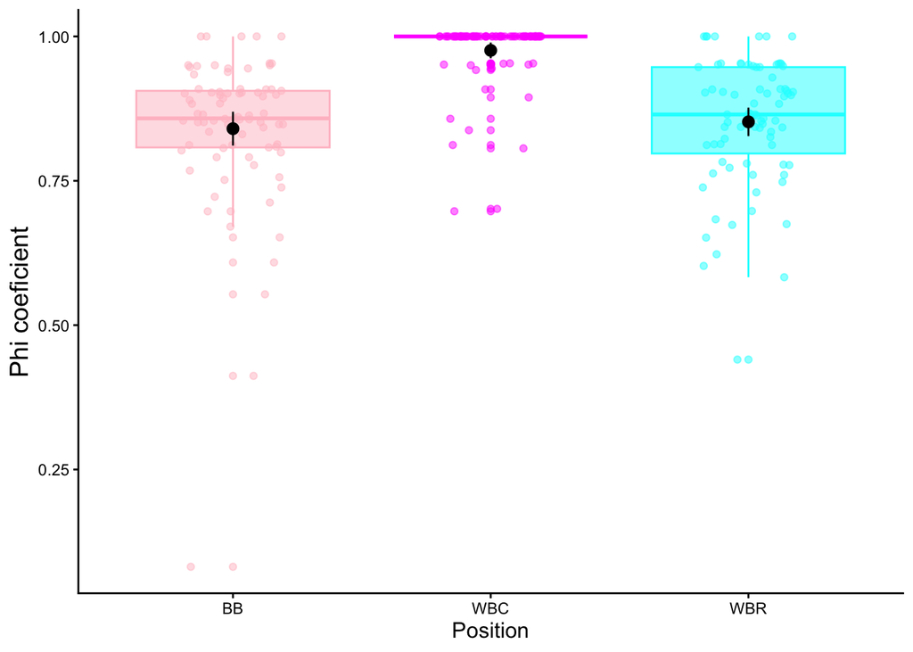

```r
# Plot the difference values for each group in 'Position'

# Function to calculate mean and confidence intervals
mean_ci <- function(x) {
  mean_x <- mean(x)
  ci <- qt(0.975, df = length(x) - 1) * sd(x) / sqrt(length(x))
  return(data.frame(y = mean_x, ymin = mean_x - ci, ymax = mean_x + ci))
}

Position_colors_violin = c(BB,WBC,WBR)

# Plot itself
ConsistencyPlot <- ggplot(sub_correlation, aes(x = Position, y = phi_coefficient, colour = Position, fill = Position)) +
  #geom_violin(alpha = 0.5) +
  geom_boxplot(alpha = 0.5)+
  scale_colour_manual(values = Position_colors_violin) +
  scale_fill_manual(values = Position_colors_violin) +
  geom_jitter(width = 0.2, alpha = 0.5) +
  stat_summary(fun.data = mean_ci, geom = "pointrange", color = "black", size = 0.5) +
  theme_classic() +
  labs(#title = "Exp 3",
       x = "Position",
       y = "Phi coeficient") +
  theme(legend.position="Position",
        axis.title.y = element_text(size = 14),
        axis.title.x = element_text(size = 12)) +
  theme(panel.background = element_rect(fill = "white"))

ConsistencyPlot
```

Creation and export of figure 1C

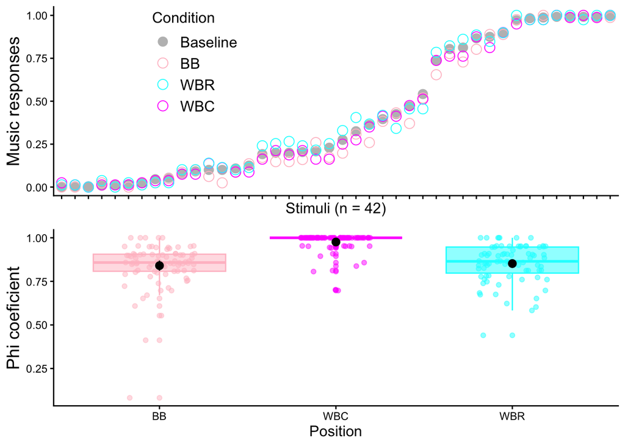

```r
Figure_1C <- grid.arrange(ResponsePlot,ConsistencyPlot,ncol = 1)
```

```r
ggsave("~/Desktop/ResponsePlot_exp3.tiff", plot = Figure_1C, width = 3, height = 5, dpi = 600, device = "tiff", compression = "lzw")
```

Comparison of listeners’ consistency (i.e., Phi coefficients) across conditions with anova and Turkey test

```r
## Test the effect of Position on the Phi coefficients with (independent measures) Anova
consistency_anova <- aov(phi_coefficient~factor(Position), data = sub_correlation)
summary(consistency_anova)
```

```
##                   Df Sum Sq Mean Sq F value   Pr(>F)
## factor(Position)   2 0.9032  0.4516   40.46 7.65e-16 ***
## Residuals        237 2.6454  0.0112
## ---
## Signif. codes:  0 '***' 0.001 '**' 0.01 '*' 0.05 '.' 0.1 ' ' 1
```

```r
# Run the ANOVA
consistency_anova <- aov(phi_coefficient ~ factor(Position), data = sub_correlation)
summary(consistency_anova)
```

```
##                   Df Sum Sq Mean Sq F value   Pr(>F)
## factor(Position)   2 0.9032  0.4516   40.46 7.65e-16 ***
## Residuals        237 2.6454  0.0112
## ---
## Signif. codes:  0 '***' 0.001 '**' 0.01 '*' 0.05 '.' 0.1 ' ' 1
```

```r
# Perform Tukey HSD post hoc test
tukey_result <- TukeyHSD(consistency_anova)

# Display the Tukey HSD result
print(tukey_result)
```

```
##   Tukey multiple comparisons of means
##     95% family-wise confidence level
##
## Fit: aov(formula = phi_coefficient ~ factor(Position), data = sub_correlation)
##
## $`factor(Position)`
##               diff         lwr         upr     p adj
## WBC-BB   0.1355419  0.09626492  0.17481894 0.0000000
## WBR-BB   0.0117657 -0.02763617  0.05116758 0.7611985
## WBR-WBC -0.1237762 -0.16329951 -0.08425295 0.0000000
```

```r
# Calculate mean and standard deviation of phi_coefficient per Position
summary_stats <- sub_correlation %>%
  group_by(Position) %>%
  summarise(
    mean_phi = mean(phi_coefficient, na.rm = TRUE),
    sd_phi = sd(phi_coefficient, na.rm = TRUE)
  )

# Print the summary statistics
print(summary_stats)
```

```
## # A tibble: 3 × 3
##   Position mean_phi sd_phi
##   <chr>       <dbl>  <dbl>
## 1 BB          0.840 0.133
## 2 WBC         0.976 0.0612
## 3 WBR         0.852 0.110
```

Plot of the two figures for Experiment 3

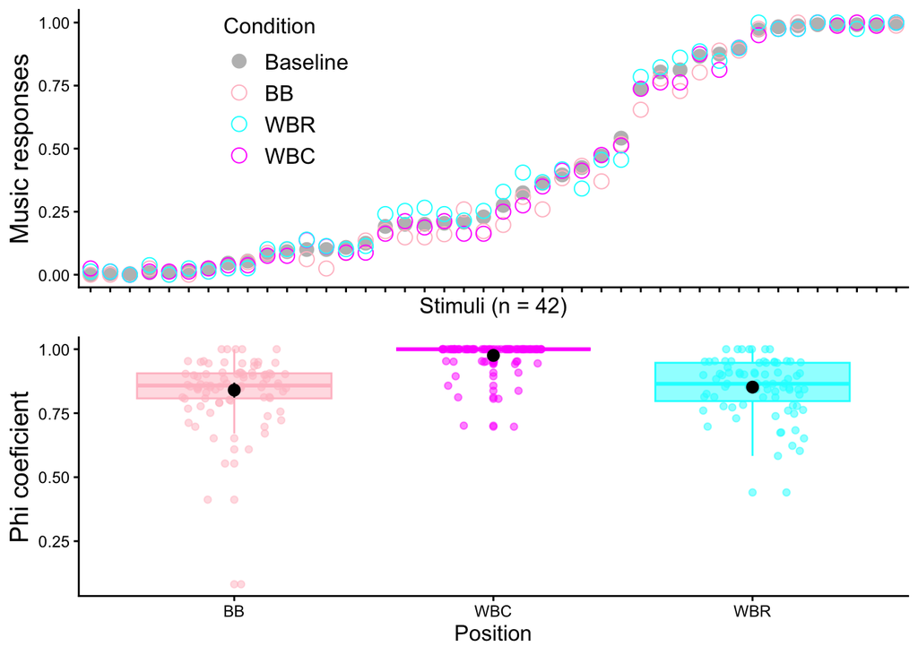

```r
Figure_1C <- grid.arrange(ResponsePlot,ConsistencyPlot,ncol = 1)
```

#Experiment 4

Loading the libraries

```r
#This package crushes with dplyr so we detach
detach("package:Hmisc", unload = TRUE)


# Load everything else first
suppressWarnings(suppressMessages(library(readr)))
suppressWarnings(suppressMessages(library(tidyr)))
suppressWarnings(suppressMessages(library(ggplot2)))
suppressWarnings(suppressMessages(library(tidyverse)))
suppressWarnings(suppressMessages(library(psych)))
suppressWarnings(suppressMessages(library(readxl)))
suppressWarnings(suppressMessages(library(patchwork)))
suppressWarnings(suppressMessages(library(caTools)))
suppressWarnings(suppressMessages(library(car)))
suppressWarnings(suppressMessages(library(quantmod)))
suppressWarnings(suppressMessages(library(MASS)))
suppressWarnings(suppressMessages(library(corrplot)))
suppressWarnings(suppressMessages(library(effects)))
suppressWarnings(suppressMessages(library(writexl)))
suppressWarnings(suppressMessages(library(stringr)))
suppressWarnings(suppressMessages(library(ape)))
suppressWarnings(suppressMessages(library(grid)))
suppressWarnings(suppressMessages(library(gridExtra)))
suppressWarnings(suppressMessages(library(dplyr)))
```

Loading the data

```r
all_data <- read_excel("all_data.xlsx",
          sheet = "Sheet1")

all_data <- all_data %>%
  relocate(exp_subject_id, .before = audio_name)

all_tasks <- read_excel("all_tasks.xlsx",
           sheet = "Sheet1")

all_tasks <- all_tasks %>%
  relocate(exp_subject_id, .before = audio_name)


demo_data <- read_excel("demo_data.xlsx",
                        sheet = "Sheet1")
```

MAIN TASK #############

Creating a dataframe for the main task, since the order of the sliders were randomized across 6 conditions, there are 6 different task names.

monra = music or not ratings (What do you think this is? 0 = not-music, 100 = music)

```r
ratings <- all_data %>%
  dplyr::select(!monra) %>%
  filter(task_name %in% c("Categorization", "Categorization2", "Categorization3", "Categorization4", "Categorization5", "Categorization6")) %>%
  left_join(
    all_data %>%
      filter(task_name %in% c("Music_or_not")) %>%
      dplyr::select(exp_subject_id, audio_name, monra),
    join_by(exp_subject_id, audio_name)
  ) %>%
  filter(!audio_group == "signal") %>%
  dplyr::select(exp_subject_id, audio_name, monra, pulse, rhythm, repetition, melody, instrumental, timbre, tempo, intentionality, harmony, complexity, pag)


#Now the long format of the same dataframe

ratings_long <- pivot_longer(ratings,
                         cols = c(monra, pulse, rhythm, repetition, melody, instrumental, timbre, tempo, intentionality, harmony, complexity), # select columns to pivot
                         names_to = "variable",     # new column name for variable names
                         values_to = "value") %>%
   mutate(levels = case_when(
    variable %in% c("instrumental", "intentionality", "complexity", "repetition") ~ 3,
    variable %in% c("harmony", "melody", "rhythm") ~ 2,
    variable %in% c("timbre", "pulse", "tempo") ~ 1,
    TRUE ~ NA_integer_  # Default case if none of the conditions match
  ))

ratings_long_wo_monra <- ratings_long %>%
  filter(!variable == "monra")
ratings_long_music <- ratings_long %>%
  filter(variable == "monra")

ratings_long2 <- pivot_longer(ratings,
                         cols = c(pulse, rhythm, repetition, melody, instrumental, timbre, tempo, intentionality, harmony, complexity), # select columns to pivot
                         names_to = "variable",     # new column name for variable names
                         values_to = "value") %>%
   mutate(levels = case_when(
    variable %in% c("instrumental", "intentionality", "complexity", "repetition") ~ 3,
    variable %in% c("harmony", "melody", "rhythm") ~ 2,
    variable %in% c("timbre", "pulse", "tempo") ~ 1,
    TRUE ~ NA_integer_  # Default case if none of the conditions match
  ))
```

I have a df with BAIS-V and Gold-MSI ratings

```r
ratings_scales <- dplyr::select(all_data, exp_subject_id, task_name, audio_name, audio_group, monra, pulse, repetition, rhythm, melody, instrumental, timbre, tempo, intentionality, harmony, complexity, ae_01, ae_02, ae_05, ae_07, baisv_01, baisv_02, baisv_03, baisv_04, baisv_05, baisv_06, baisv_07, baisv_08, baisv_09, baisv_10, baisv_11, baisv_12, baisv_13, baisv_14, mt_01, mt_02, mt_03, mt_06, mt_07, pa_04, pa_08, sa_01, sa_02, sa_03, sa_04, sa_05, sa_06, em_04)

ratings <- all_data %>%
  dplyr::select(exp_subject_id, task_name, audio_name, audio_group, monra, pulse, repetition, rhythm, melody, instrumental, timbre, tempo, intentionality, harmony, complexity) %>%
  na.omit()


ratings <- all_data %>%
  filter(task_name %in% c("Categorization", "Categorization2", "Categorization3", "Categorization4", "Categorization5", "Categorization6")) %>%
  dplyr::select(exp_subject_id, audio_name, pulse, repetition, rhythm, melody, instrumental, timbre, tempo, intentionality, harmony, complexity) %>%
  left_join(
    all_data %>%
      filter(!audio_group == "signal") %>%
      filter(task_name %in% c("Music_or_not")) %>%
      dplyr::select(exp_subject_id, audio_name, monra),
    join_by(exp_subject_id, audio_name)
  )
```

Filter only categorization task and then filter out the signal sounds

```r
#Only ratings of perceptual features

features_data <- ratings_scales %>%
  filter(task_name %in% c("Categorization", "Categorization2", "Categorization3", "Categorization4", "Categorization5", "Categorization6"),
         !audio_group == "signal") %>%
  dplyr::select(exp_subject_id, audio_name, pulse, rhythm, repetition, melody, instrumental, timbre, tempo, intentionality, harmony, complexity)

#Only music or not ratings
monra_data <- ratings_scales %>%
  filter(task_name %in% c("Music_or_not"),
         !audio_group == "signal") %>%
  dplyr::select(exp_subject_id, audio_name, monra)

write_xlsx(monra_data, "monra_data.xlsx")
```

Data Frames for MM1 analysis

```r
monra_mm1 <- monra_data %>%
  pivot_wider(names_from = audio_name, values_from = monra)

pulse_mm1 <- features_data %>%
  dplyr::select(exp_subject_id, audio_name, pulse) %>%
  pivot_wider(names_from = audio_name, values_from = pulse)

repetition_mm1 <- features_data %>%
  dplyr::select(exp_subject_id, audio_name, repetition) %>%
  pivot_wider(names_from = audio_name, values_from = repetition)

rhythm_mm1 <- features_data %>%
  dplyr::select(exp_subject_id, audio_name, rhythm) %>%
  pivot_wider(names_from = audio_name, values_from = rhythm)

melody_mm1 <- features_data %>%
  dplyr::select(exp_subject_id, audio_name, melody) %>%
  pivot_wider(names_from = audio_name, values_from = melody)

instrumental_mm1 <- features_data %>%
  dplyr::select(exp_subject_id, audio_name, instrumental) %>%
  pivot_wider(names_from = audio_name, values_from = instrumental)

timbre_mm1 <- features_data %>%
  dplyr::select(exp_subject_id, audio_name, timbre) %>%
  pivot_wider(names_from = audio_name, values_from = timbre)

tempo_mm1 <- features_data %>%
  dplyr::select(exp_subject_id, audio_name, tempo) %>%
  pivot_wider(names_from = audio_name, values_from = tempo)

intentionality_mm1 <- features_data %>%
  dplyr::select(exp_subject_id, audio_name, intentionality) %>%
  pivot_wider(names_from = audio_name, values_from = intentionality)

harmony_mm1 <- features_data %>%
  dplyr::select(exp_subject_id, audio_name, harmony) %>%
  pivot_wider(names_from = audio_name, values_from = harmony)

complexity_mm1 <- features_data %>%
  dplyr::select(exp_subject_id, audio_name, complexity) %>%
  pivot_wider(names_from = audio_name, values_from = complexity)
```

A more descriptive DF that we will use, the mean ratings of all sliders (monra + features) at the stimulus level.

```r
audio_descriptives <- ratings %>%
  group_by(audio_name) %>%
  summarize(
            mean_monra = mean(monra, na.rm = TRUE),
            mean_pulse = mean(pulse, na.rm = TRUE),
            mean_repetition = mean(repetition, na.rm = TRUE),
            mean_rhythm = mean(rhythm, na.rm = TRUE),
            mean_melody = mean(melody, na.rm = TRUE),
            mean_instrumental = mean(instrumental, na.rm = TRUE),
            mean_timbre = mean(timbre, na.rm = TRUE),
            mean_tempo = mean(tempo, na.rm = TRUE),
            mean_intentionality = mean(intentionality, na.rm = TRUE),
            mean_harmony = mean(harmony, na.rm = TRUE),
            mean_complexity = mean(complexity, na.rm = TRUE))


audio_descriptives_long <- pivot_longer(audio_descriptives,
                                  cols = c(mean_monra, mean_pulse, mean_rhythm, mean_repetition, mean_melody, mean_instrumental,
                                                 mean_timbre, mean_tempo, mean_intentionality, mean_harmony, mean_complexity),
                                  names_to = "variable",
                                  values_to = "value")
```

We do the k-means clustering here. This is because the clusters will then be used for further analysis etc. and I thought it makes more sense to put the cluster analysis here.

For the sake of ease, we assign the value 1 to the cluster with the highest mean (music), and 3 to the cluster with the lowest value (not-music)

```r
# Assuming you have loaded your data frame 'audio_descriptives' correctly
justmeans <- dplyr::select(audio_descriptives, audio_name, mean_monra)

# Perform k-means clustering
set.seed(123)  # for reproducibility of the k-means itself
kmm <- kmeans(justmeans$mean_monra, 3, nstart = 50, iter.max = 15)
print(kmm)
```

```
## K-means clustering with 3 clusters of sizes 36, 36, 18
##
## Cluster means:
##       [,1]
## 1 87.45295
## 2 12.78770
## 3 52.44615
##
## Clustering vector:
##  [1] 1 1 1 1 1 1 1 1 1 1 3 1 1 1 1 1 1 1 2 3 2 3 3 2 3 3 3 3 1 1 1 1 1 1 1 1 1 1
## [39] 1 1 1 1 1 1 1 1 3 3 3 1 2 2 2 2 3 2 3 2 2 2 2 3 2 2 3 3 2 2 2 2 2 2 2 2 2 3
## [77] 2 2 2 2 2 2 2 2 2 2 2 3 2 2
##
## Within cluster sum of squares by cluster:
## [1] 2113.655 1879.441 1563.415
##  (between_SS / total_SS =  94.8 %)
##
## Available components:
##
## [1] "cluster"      "centers"      "totss"        "withinss"     "tot.withinss"
## [6] "betweenss"    "size"         "iter"         "ifault"
```

```r
print(kmm$betweenss / kmm$totss)
```

```
## [1] 0.9475715
```

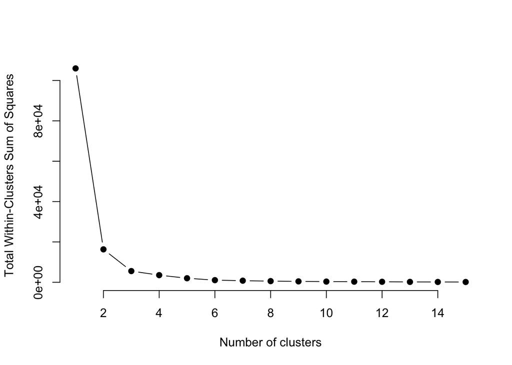

```r
# --- Relabel clusters so that 1 = highest mean, 3 = lowest mean ---
# Get the centers (one per cluster) and rank them from highest to lowest
centers <- kmm$centers[, 1]                 # vector of cluster means
ranked  <- order(centers, decreasing = TRUE)  # which old label is 1st, 2nd, 3rd highest

# Build a lookup: old cluster id -> new cluster id
# ranked[1] is the old id of the highest-mean cluster -> should become 1
# ranked[2] -> 2, ranked[3] -> 3
relabel <- setNames(seq_along(ranked), ranked)

# Apply the relabeling
new_clusters <- relabel[as.character(kmm$cluster)]

# Method 1: Elbow Method for finding the optimal number of clusters
set.seed(123)
k.max <- 15
data <- na.omit(justmeans$mean_monra)
wss <- sapply(1:k.max, function(k) {
  kmeans(data, k, nstart = 50, iter.max = 15)$tot.withinss
})
plot(1:k.max, wss,
     type = "b", pch = 19, frame = FALSE,
     xlab = "Number of clusters",
     ylab = "Total Within-Clusters Sum of Squares")
```

```r
# Add the relabeled cluster assignments to the data frame
justmeans <- justmeans %>%
  mutate(cluster = as.integer(new_clusters))

# Quick sanity check: cluster 1 should have the highest mean, cluster 3 the lowest
justmeans %>%
  group_by(cluster) %>%
  summarise(mean_value = mean(mean_monra, na.rm = TRUE),
            n = n()) %>%
  arrange(cluster)
```

| cluster | mean_value | n |
| --- | --- | --- |
| 1 | 87.45295 | 36 |
| 2 | 52.44615 | 18 |
| 3 | 12.78770 | 36 |

```r
head(justmeans)
```

| audio_name | mean_monra | cluster |
| --- | --- | --- |
| M_apocalyptic_guitar.mp3 | 83.73469 | 1 |
| M_asian_flute.mp3 | 93.67347 | 1 |
| M_asian_guitar1.mp3 | 95.41837 | 1 |
| M_bahriyya.mp3 | 71.23469 | 1 |
| M_beats_experimental1.mp3 | 74.44898 | 1 |
| M_beats_experimental2.mp3 | 81.08163 | 1 |

Renaming the clusters

```r
# Create a separate data frame with audio_name and cluster

audio_clusters <- justmeans %>%
  dplyr::select(audio_name, cluster) %>%
  mutate(label = case_when(
    cluster == 1 ~ "music",
    cluster == 2 ~ "ambiguous",
    cluster == 3 ~ "non-music"))

audio_clusters <- audio_clusters %>%
  mutate(clean_names = audio_name %>%
           gsub("^(M_|N_)", "", .) %>%  # Remove M_ or N_ at the start
           gsub("\\.mp3$", "", .) %>%  # Remove .mp3 at the end
           gsub("_", " ", .) %>%       # Replace underscores with spaces
           str_to_title()              # Capitalize each word
         )
audio_descriptives <- merge(audio_descriptives, audio_clusters, by = "audio_name")


ratings <- ratings %>%
  left_join(audio_clusters %>%
              dplyr::select(audio_name, label, cluster),
            by = "audio_name")

ratings_long <- ratings_long %>%
  left_join(audio_clusters %>%
              dplyr::select(audio_name, label),
            by = "audio_name")


ratings_long_wo_monra <- ratings_long_wo_monra %>%
  left_join(audio_clusters %>%
              dplyr::select(audio_name, label),
            by = "audio_name")

ratings_lme <- ratings

write_xlsx(audio_descriptives, "audio_descriptives.xlsx")

write_xlsx(ratings, "ratings.xlsx")
```

Participant means, average values at the participant level

```r
participant_means <- ratings %>%
  group_by(exp_subject_id) %>%
  summarize(across(.cols = c(monra, pulse, rhythm, repetition, melody, instrumental, timbre, tempo, intentionality, harmony, complexity), .fns = mean))

#Computing "music bias", i.e., participants' mean ratings for only ambiguous stimuli.

participant_music_bias <- ratings %>%
  group_by(exp_subject_id) %>%
  filter(label == "ambiguous") %>%
  summarize(across(.cols = c(monra, pulse, rhythm, repetition, melody, instrumental, timbre, tempo, intentionality, harmony, complexity), .fns = mean)) %>%
  rename(music_bias = monra) %>%
  dplyr::select(exp_subject_id, music_bias)
```

Calculate Gold-MSI and BAIS-V

```r
# ---- Gold-MSI ----
gold_items <- c("ae_01","ae_02","ae_05","ae_07",
                "mt_01","mt_02","mt_03","mt_06","mt_07",
                "pa_04","pa_08",
                "sa_01","sa_02","sa_03","sa_04","sa_05","sa_06",
                "em_04")

gold <- all_tasks %>%
  dplyr::select(exp_subject_id, all_of(gold_items)) %>%
  group_by(exp_subject_id) %>%
  summarise(across(everything(), ~ .x[!is.na(.x)][1]), .groups = "drop")

# Reverse-code on the items only, but keep IDs aligned by binding back immediately
keys_gold <- c("sa_05", "sa_04", "mt_03", "mt_07", "pa_08")
rec <- psych::reverse.code(keys = keys_gold,
                           items = gold %>% dplyr::select(-exp_subject_id),
                           mini = 1, maxi = 7) %>% as.data.frame()

# Reverse-coded columns get a "-" suffix; reference them with backticks
gold_score <- gold %>%
  dplyr::select(exp_subject_id) %>%
  mutate(gold = rowSums(cbind(
    rec$ae_01, rec$ae_02, rec$ae_05, rec$ae_07, rec$em_04,
    rec$mt_01, rec$mt_02, rec$`mt_03-`, rec$mt_06, rec$`mt_07-`,
    rec$pa_04, rec$`pa_08-`,
    rec$sa_01, rec$sa_02, rec$sa_03, rec$`sa_04-`, rec$`sa_05-`, rec$sa_06
  )))

# ---- BAIS-V ----
bais_items <- paste0("baisv_", sprintf("%02d", 1:14))

bais <- all_tasks %>%
  dplyr::select(exp_subject_id, all_of(bais_items)) %>%
  group_by(exp_subject_id) %>%
  summarise(across(everything(), ~ .x[!is.na(.x)][1]), .groups = "drop") %>%
  na.omit()  # drops subjects missing any BAIS item; ID stays attached

BAIS_score <- bais %>%
  mutate(bais = rowMeans(dplyr::select(., all_of(bais_items)))) %>%
  dplyr::select(exp_subject_id, bais)

# ---- Combine by ID, not by position ----
scales <- full_join(gold_score, BAIS_score, by = "exp_subject_id")
```

Calculate Openness

```r
openness <- dplyr::select(all_tasks, exp_subject_id, open1, open2, open3, open4, open5, open6, open7, open8, open9, open10)

reverse_code <- function(x) {
  return(6 - x)
}

# Apply reverse coding and calculate total_openness
openness <- openness %>%
  mutate(
    open2 = reverse_code(open2),
    open4 = reverse_code(open4),
    open6 = reverse_code(open6),
    open8 = reverse_code(open8),
    open10 = reverse_code(open10)
  ) %>%
  group_by(exp_subject_id) %>%
  summarise(total_openness = sum(c_across(open1:open10), na.rm = TRUE))

# View the result
print(openness)
```

```
## # A tibble: 98 × 2
##    exp_subject_id total_openness
##             <dbl>          <dbl>
##  1         937114             39
##  2         937115             37
##  3         937117             46
##  4         937126             44
##  5         937138             43
##  6         937151             39
##  7         937164             36
##  8         937267             42
##  9         943497             36
## 10         943525             29
## # ℹ 88 more rows
```

```r
all_scales <- merge(scales, openness, by ="exp_subject_id")
all_scales <- all_scales

#Summary stats of scales

mean(all_scales$total_openness)
```

```
## [1] 38.18367
```

```r
sd(all_scales$total_openness)
```

```
## [1] 6.381912
```

```r
min(all_scales$total_openness)
```

```
## [1] 18
```

```r
max(all_scales$total_openness)
```

```
## [1] 50
```

```r
mean(all_scales$bais)
```

```
## [1] 4.786443
```

```r
sd(all_scales$bais)
```

```
## [1] 1.020539
```

```r
min(all_scales$bais)
```

```
## [1] 1
```

```r
max(all_scales$bais)
```

```
## [1] 6.928571
```

```r
mean(all_scales$gold)
```

```
## [1] 71.45918
```

```r
sd(all_scales$gold)
```

```
## [1] 19.78397
```

```r
min(all_scales$gold)
```

```
## [1] 29
```

```r
max(all_scales$gold)
```

```
## [1] 114
```

Computing how well participants understood the definitions of features that we provided.

```r
understanding <- all_tasks %>%
  dplyr::select(exp_subject_id, pulseund, melodyund, instrumentalund, timbreun, tempound, intentionalityund, harmonyund, complexityund, toneund, rhythmund) %>%
  na.omit() %>%
  group_by(exp_subject_id) %>%
  summarise(total_und = sum(c_across(pulseund:rhythmund)))

understanding_perfeature <- all_tasks %>%
  dplyr::select(exp_subject_id, pulseund, melodyund, instrumentalund, timbreun, tempound, intentionalityund, harmonyund, complexityund, toneund, rhythmund) %>%
  na.omit()

understanding_long <- pivot_longer(understanding_perfeature,
                                  cols = c(pulseund, melodyund, instrumentalund, timbreun,
                                           tempound, intentionalityund, harmonyund, complexityund, toneund, rhythmund),
                                  names_to = "variable",
                                  values_to = "value")

understanding_with_scales <- merge(understanding, all_scales, by = "exp_subject_id")

all_scales <- all_scales %>%
  left_join(participant_music_bias %>%
              dplyr::select(exp_subject_id, music_bias),
            by = "exp_subject_id")
```

Calculate the mean age and gender information

```r
# Age statistics
age_mean <- mean(demo_data$age, na.rm = TRUE)
age_sd <- sd(demo_data$age, na.rm = TRUE)
age_min <- min(demo_data$age, na.rm = TRUE)
age_max <- max(demo_data$age, na.rm = TRUE)

# Gender distribution
gender_counts <- table(demo_data$gender)

# Print results in full sentences
cat(
  paste0("The mean age of participants is ", round(age_mean, 2),
         ", with a standard deviation of ", round(age_sd, 2),
         ". The youngest participant is ", age_min,
         " years old, and the oldest is ", age_max, " years old.\n\n"),

  paste0("The gender distribution is as follows:\n"),
  paste0(names(gender_counts), ": ", gender_counts, collapse = "\n")
)
```

```
## The mean age of participants is 34.98, with a standard deviation of 11.32. The youngest participant is 18 years old, and the oldest is 74 years old.
##
##  The gender distribution is as follows:
##  female: 30
## male: 68
```

Put the average rating for each participant to the scales df

```r
means_scales <- merge(all_scales, participant_means, by = "exp_subject_id")

means_scales_age <- means_scales %>%
  left_join(demo_data %>%
              dplyr::select(exp_subject_id, age),
              by = "exp_subject_id")
```

A DF just for the ambiguous stimuli

```r
ambiguous_stimuli <- ratings %>%
  filter(label == "ambiguous")

ambiguous_participant_means <- ambiguous_stimuli %>%
  group_by(exp_subject_id) %>%
  summarize(mean_monra = mean(monra)) %>%
  dplyr::select(exp_subject_id, mean_monra)
```

Circular cluster plot for the paper, included in Figure 2A

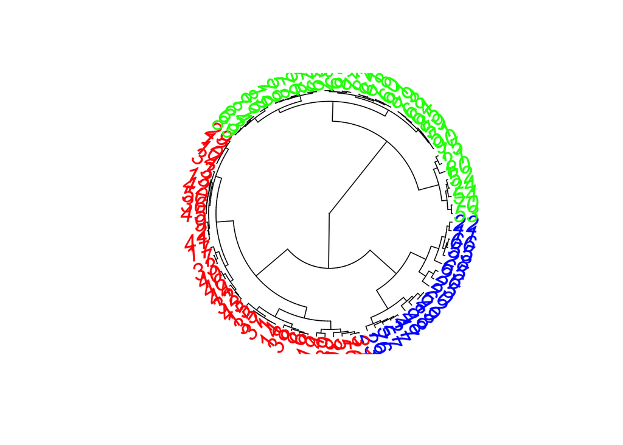

```r
# Reorder the audio_name based on the label to group the clusters
audio_clusters <- audio_clusters[order(audio_clusters$label), ]

audio_clusters$audio_name <- as.character(audio_clusters$audio_name)

# Step 1: Order the dataframe alphabetically including prefixes
audio_clusters <- audio_clusters %>%
  arrange(audio_name)
audio_clusters$number <- 1:nrow(audio_clusters)  # Assign numbers sequentially


audio_clusters <- audio_clusters %>%
  mutate(clean_names = str_replace(audio_name, '^(.+)\\.mp3$', '\\1')) %>%
  mutate(clean_names = str_to_title(clean_names))


distance_mat <- dist(audio_descriptives$mean_monra, method = 'euclidean')


# Fitting Hierarchical clustering Model to training dataset
set.seed(240) # Setting seed
Hierar_cl <- hclust(distance_mat, method = "average")


# Assuming 'Hierar_cl' is your hclust result and 'fit' contains cluster assignments
phylo_tree <- as.phylo(Hierar_cl)  # Convert hclust to phylo object
fit <- cutree(Hierar_cl, k = 3)

# Define your cluster colors
# Ensure 'fit' is a vector containing cluster assignments for each tip
colors <- c("red", "blue", "green")  # 1 = red, 2 = blue, 3 = green
tip_colors <- colors[fit]  # Map the cluster assignments to colors

# Plot the circular dendrogram with color-coded tips
plot(phylo_tree,
     type = "fan",       # Circular plot
     tip.color = tip_colors,  # Color tips based on clusters
     label.offset = 0.01,  # Space between tips and labels
     cex = 1.6,           # Text size
     show.tip.label = TRUE)  # Show labels (audio names)
```

[figure not shown]

```r
# Define colors for each cluster
label_colors <- c("music" = "red", "ambiguous" = "blue", "non-music" = "green")

# Create a blank plot for printing the text
grid.newpage()

# Set up the column positions
x_positions <- c(0.1, 0.4, 0.7)  # X coordinates for the 3 columns

# Loop through each row and assign text to the correct column and row position
for (i in 1:nrow(audio_clusters)) {
  # Determine the column (1st, 2nd, or 3rd column)
  column <- ((i - 1) %/% 30) + 1
  row <- (i - 1) %% 30 + 1

  # Calculate the y position for each row (invert row index for grid positioning)
  y_position <- 1 - (row * 0.03)  # Adjust spacing between rows

  # Print the text in the correct column, color-coded by cluster
  grid.text(
    label = paste(audio_clusters$number[i], "-", audio_clusters$clean_names[i]),
    x = x_positions[column],
    y = y_position,
    gp = gpar(col = label_colors[audio_clusters$label[i]], fontsize = 20),
    just = "left"
  )
}
```

Plotting the participants and audios ordered by mean (Figure 2B)

The first column represent the mean music ratings ordered from high (on top) to low (on the bottom). Then, every other column is the ranking of each participant’s music ratings.

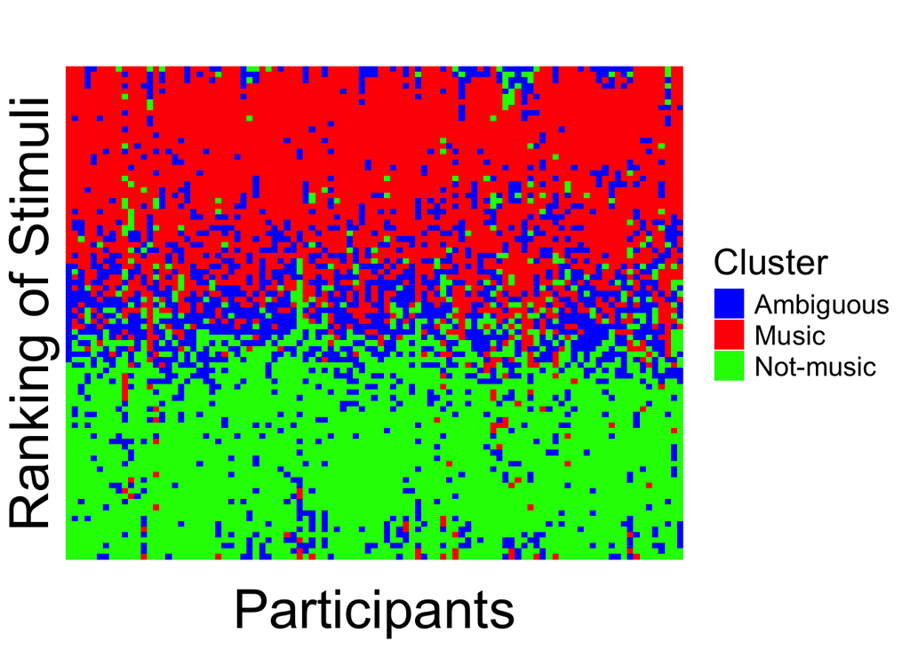

```r
# Reshaping the dataframe
monra_mm1_long <- monra_mm1 %>%
  pivot_longer(
    cols = -exp_subject_id,  # Keep exp_subject_id, gather other columns
    names_to = "audio_name",  # The names of the audio columns will go to this new column
    values_to = "rating"      # The ratings will go to this new column
  )

# Now pivot wider so that exp_subject_id becomes columns
monra_mm1_wide <- monra_mm1_long %>%
  pivot_wider(
    names_from = exp_subject_id,  # The exp_subject_id values become new columns
    values_from = rating          # Values come from the rating column
  )


monra_mean_participants <- monra_mm1_wide %>%
  left_join(audio_descriptives %>% dplyr::select(audio_name, mean_monra), by = "audio_name") %>%
  relocate(mean_monra, .after = audio_name) %>%
  left_join(audio_clusters %>% dplyr::select(audio_name, label), by = "audio_name") %>%
  relocate(label, .after = mean_monra)

# Step 1: Reshape the original data to long format for participant ratings
long_data <- monra_mean_participants %>%
  pivot_longer(
    cols = -c(audio_name, mean_monra, label),  # Exclude non-participant columns
    names_to = "participant_id",
    values_to = "rating"
  ) %>%
  dplyr::group_by(participant_id) %>%
  dplyr::arrange(rating, .by_group = TRUE) %>%
  mutate(rank = row_number())  # Assign rank based on the order of ratings within each participant

# Step 2: Create a long format for mean_monra
mean_monra_long <- monra_mean_participants %>%
  dplyr::select(audio_name, mean_monra, label) %>%
  mutate(participant_id = "mean_monra", rating = mean_monra) %>%
  dplyr::select(audio_name, participant_id, rating, label)

# Step 3: Combine both long formats
combined_long_data <- bind_rows(long_data, mean_monra_long)

# Step 4: Adjust the participant_id to make mean_monra first
combined_long_data <- combined_long_data %>%
  mutate(participant_id = factor(participant_id, levels = c("mean_monra", unique(long_data$participant_id))))  # Ensures mean_monra is first

# Step 5: Rank the combined data
combined_long_data <- combined_long_data %>%
  dplyr::group_by(participant_id) %>%
  dplyr::arrange(rating, .by_group = TRUE) %>%
  mutate(rank = row_number())  # Assign rank for all participants including mean_monra

# Step 6: Create the plot
ggplot(combined_long_data, aes(x = participant_id, y = rank, fill = label)) +
  geom_tile() +
  scale_fill_manual(
    values = c("music" = "red", "ambiguous" = "blue", "non-music" = "green"),
    labels = c("music" = "Music", "ambiguous" = "Ambiguous", "non-music" = "Not-music")
  ) +
  labs(
    x = "Participants",
    y = "Ranking of Stimuli",
    title = " ",
    fill = "Cluster"
  ) +
  theme_minimal() +
  theme(
    axis.text.x = element_blank(),
    axis.title.x = element_text(size = 30),
    axis.text.y = element_blank(),
    axis.title.y = element_text(size = 30),
    panel.grid = element_blank(),
    legend.text = element_text(size = 15),
    legend.title = element_text(size = 20),
    axis.text.x.left = element_text(
      ifelse(unique(combined_long_data$participant_id) == "mean_monra", "black", "transparent")
    )
  )
```

Experiment 4 Analyses

```r
# install.packages("irr")
# install.packages("lmerTest")
# install.packages("MuMIn")
# install.packages("factoextra")
# install.packages("simr")
# install.packages("car")
# install.packages("sjPlot")
# install.packages("ggsignif")
# install.packages("gridExtra")
# install.packages("emmeans")
# install.packages("ggradar")
# install.packages("fmsb")
# install.packages("effects")
# install.packages("nnet")
# install.packages("MASS")
# install.packages("multcomp")
# install.packages("ggsignif")
# install.packages("ggrepel")
# #install.packages("ggradar")
# install.packages("effects")
# install.packages("poLCA")
# install.packages("lcmm")
# install.packages("mclust")
# install.packages("rcompanion")
# install.packages("pscl")
#install.packages("ordinal")

options(scipen=999)
suppressWarnings(suppressMessages(library(car)))
suppressWarnings(suppressMessages(library(corrplot)))
suppressWarnings(suppressMessages(library(dplyr)))
suppressWarnings(suppressMessages(library(effects)))
suppressWarnings(suppressMessages(library(emmeans)))
suppressWarnings(suppressMessages(library(factoextra)))
suppressWarnings(suppressMessages(library(fmsb)))
suppressWarnings(suppressMessages(library(ggrepel)))
suppressWarnings(suppressMessages(library(ggsignif)))
suppressWarnings(suppressMessages(library(gridExtra)))
suppressWarnings(suppressMessages(library(irr)))
suppressWarnings(suppressMessages(library(lcmm)))
suppressWarnings(suppressMessages(library(lme4)))
suppressWarnings(suppressMessages(library(lmerTest)))
suppressWarnings(suppressMessages(library(MASS)))
suppressWarnings(suppressMessages(library(mclust)))
suppressWarnings(suppressMessages(library(MuMIn)))
suppressWarnings(suppressMessages(library(multcomp)))
suppressWarnings(suppressMessages(library(nnet)))
suppressWarnings(suppressMessages(library(ordinal)))
suppressWarnings(suppressMessages(library(poLCA)))
suppressWarnings(suppressMessages(library(pscl)))
suppressWarnings(suppressMessages(library(rcompanion)))
suppressWarnings(suppressMessages(library(simr)))
suppressWarnings(suppressMessages(library(sjPlot)))
suppressWarnings(suppressMessages(library(tidyr)))
```

MM1 for monra

Overall MM1 value for music ratings is .87. This is very high, so participants to agree with each other. This is reported in the paper.

```r
MM1_revised <- function(df){
  #save & remove subj id
  id <- df[, 1]
  df <- as.matrix(df[,-1])

  #Compute means minus one
  means <- matrix(0, nrow = nrow(df), ncol = ncol(df))
  for(j in 1:nrow(df)){
    means[j,] <- colMeans(df[-j,])
  }

  #Compute correlations between means minus ones and ones ratings
  mm1 <- sapply(1:nrow(df), function(.x) cor(df[.x,], means[.x,]))

  #transform correlations into z scores (r to z Fisher)
  z_scores <- sapply(mm1, function(x) log((1 + x)/(1 - x))) * .5

  #save average correlation (z average to r average Fisher) and correlations per rater
  result <-  list(MM1 = (exp(2 * (mean(z_scores))) - 1)/(exp( 2 * (mean(z_scores))) + 1),
                  raw = data.frame(id, mm1 = mm1, mm1_z = z_scores))
  result
}

#MM1 list
MM1_List <- MM1_revised(monra_mm1)

MM1_L <- as.data.frame(MM1_List$raw)

cat(paste0("MM1 for music ratings is ", round(MM1_List$MM1, 2),
           ", indicating high agreement among participants."))
```

```
## MM1 for music ratings is 0.87, indicating high agreement among participants.
```

MM1 for each features (Reported)

For higher level features, there is more agreement, for lower level features, there is less.

```r
MM1_repetition <- MM1_revised(repetition_mm1)
MM1_repetition$MM1
```

```
## [1] 0.4167283
```

```r
MM1_pulse <- MM1_revised(pulse_mm1)
MM1_pulse$MM1
```

```
## [1] 0.6281115
```

```r
MM1_rhythm <- MM1_revised(rhythm_mm1)
MM1_rhythm$MM1
```

```
## [1] 0.6734365
```

```r
MM1_melody <- MM1_revised(melody_mm1)
MM1_melody$MM1
```

```
## [1] 0.787064
```

```r
MM1_instrumental <- MM1_revised(instrumental_mm1)
MM1_instrumental$MM1
```

```
## [1] 0.8323992
```

```r
MM1_timbre <- MM1_revised(timbre_mm1)
MM1_timbre$MM1
```

```
## [1] 0.6026743
```

```r
MM1_tempo <- MM1_revised(tempo_mm1)
MM1_tempo$MM1
```

```
## [1] 0.5776043
```

```r
MM1_intentionality <- MM1_revised(intentionality_mm1)
MM1_intentionality$MM1
```

```
## [1] 0.7481585
```

```r
MM1_harmony <- MM1_revised(harmony_mm1)
MM1_harmony$MM1
```

```
## [1] 0.7194582
```

```r
MM1_complexity <- MM1_revised(complexity_mm1)
MM1_complexity$MM1
```

```
## [1] 0.6734471
```

Krippendorff’s alpha for each rating, at the group level. (Reported)

```r
monra_krip <- monra_mm1 %>%
  dplyr::select(!exp_subject_id)

monra_krip <- as.matrix(monra_krip)

kripp.alpha(monra_krip, method = "interval")
```

```
##  Krippendorff's alpha
##
##  Subjects = 90
##    Raters = 98
##     alpha = 0.684
```

```r
intentionality_krip <- intentionality_mm1 %>%
  dplyr::select(!exp_subject_id)

intentionality_krip <- as.matrix(intentionality_krip)

kripp.alpha(intentionality_krip, method = "interval")
```

```
##  Krippendorff's alpha
##
##  Subjects = 90
##    Raters = 98
##     alpha = 0.478
```

```r
instrumental_krip <- instrumental_mm1 %>%
  dplyr::select(!exp_subject_id)

instrumental_krip <- as.matrix(instrumental_krip)

kripp.alpha(instrumental_krip, method = "interval")
```

```
##  Krippendorff's alpha
##
##  Subjects = 90
##    Raters = 98
##     alpha = 0.622
```

```r
complexity_krip <- complexity_mm1 %>%
  dplyr::select(!exp_subject_id)

complexity_krip <- as.matrix(complexity_krip)

kripp.alpha(complexity_krip, method = "interval")
```

```
##  Krippendorff's alpha
##
##  Subjects = 90
##    Raters = 98
##     alpha = 0.367
```

```r
repetition_krip <- repetition_mm1 %>%
  dplyr::select(!exp_subject_id)

repetition_krip <- as.matrix(repetition_krip)

kripp.alpha(repetition_krip, method = "interval")
```

```
##  Krippendorff's alpha
##
##  Subjects = 90
##    Raters = 98
##     alpha = 0.115
```

```r
melody_krip <- melody_mm1 %>%
  dplyr::select(!exp_subject_id)

melody_krip <- as.matrix(melody_krip)

kripp.alpha(melody_krip, method = "interval")
```

```
##  Krippendorff's alpha
##
##  Subjects = 90
##    Raters = 98
##     alpha = 0.539
```

```r
rhythm_krip <- rhythm_mm1 %>%
  dplyr::select(!exp_subject_id)

rhythm_krip <- as.matrix(rhythm_krip)

kripp.alpha(rhythm_krip, method = "interval")
```

```
##  Krippendorff's alpha
##
##  Subjects = 90
##    Raters = 98
##     alpha = 0.369
```

```r
harmony_krip <- harmony_mm1 %>%
  dplyr::select(!exp_subject_id)

harmony_krip <- as.matrix(harmony_krip)

kripp.alpha(harmony_krip, method = "interval")
```

```
##  Krippendorff's alpha
##
##  Subjects = 90
##    Raters = 98
##     alpha = 0.422
```

```r
timbre_krip <- timbre_mm1 %>%
  dplyr::select(!exp_subject_id)

timbre_krip <- as.matrix(timbre_krip)

kripp.alpha(timbre_krip, method = "interval")
```

```
##  Krippendorff's alpha
##
##  Subjects = 90
##    Raters = 98
##     alpha = 0.285
```

```r
tempo_krip <- tempo_mm1 %>%
  dplyr::select(!exp_subject_id)

tempo_krip <- as.matrix(tempo_krip)

kripp.alpha(tempo_krip, method = "interval")
```

```
##  Krippendorff's alpha
##
##  Subjects = 90
##    Raters = 98
##     alpha = 0.247
```

```r
pulse_krip <- pulse_mm1 %>%
  dplyr::select(!exp_subject_id)

pulse_krip <- as.matrix(pulse_krip)

kripp.alpha(pulse_krip, method = "interval")
```

```
##  Krippendorff's alpha
##
##  Subjects = 90
##    Raters = 98
##     alpha = 0.31
```

The list below is based on the origin of the excerpts

```r
non_western_mp3 <- c(
  "M_asian_flute.mp3",
  "M_asian_guitar1.mp3",
  "M_bahriyya.mp3",
  "M_bells.mp3",
  "M_bilal.mp3",
  "M_caballo_blanco.mp3",
  "M_drums_maraka.mp3",
  "M_dundun6M.mp3",
  "M_faa_gani.mp3",
  "M_ganza_knogo_ngo.mp3",
  "M_gogi.mp3",
  "M_gonul_kalk.mp3",
  "M_indian_vina2.mp3",
  "M_kiva_nariako.mp3",
  "M_latin_guitar.mp3",
  "M_mariposa.mp3",
  "M_mawal_ma_raqsa.mp3",
  "M_mugam.mp3",
  "M_phen_phi_fa.mp3",
  "M_ungava_bay.mp3",
  "M_ungava_bay_2.mp3",
  "M_water_drum.mp3",
  "M_zapateada_criollo.mp3"
)

ratings <- ratings %>%
  mutate(culture = if_else(audio_name %in% non_western_mp3, "non-western", "western"))

ratings <- ratings %>%
  mutate(apriori_group = if_else(startsWith(audio_name, "M_"), "music", "not-music"))

ratings_music <- ratings |>
  filter(label == "music")

ratings_music_apriori <- ratings |>
  filter(apriori_group == "music")
```

```r
cc_difference <- lmer(monra ~ culture + (1 | exp_subject_id) + (1 | audio_name), data = ratings_music)

summary(cc_difference)
```

```
## Linear mixed model fit by REML. t-tests use Satterthwaite's method [
## lmerModLmerTest]
## Formula: monra ~ culture + (1 | exp_subject_id) + (1 | audio_name)
##    Data: ratings_music
##
## REML criterion at convergence: 29845.8
##
## Scaled residuals:
##     Min      1Q  Median      3Q     Max
## -5.8510 -0.3040  0.1316  0.5564  3.2024
##
## Random effects:
##  Groups         Name        Variance Std.Dev.
##  exp_subject_id (Intercept) 119.87   10.949
##  audio_name     (Intercept)  56.38    7.509
##  Residual                   247.61   15.736
## Number of obs: 3528, groups:  exp_subject_id, 98; audio_name, 36
##
## Fixed effects:
##                Estimate Std. Error     df t value            Pr(>|t|)
## (Intercept)      85.698      2.120 60.835  40.418 <0.0000000000000002 ***
## culturewestern    3.510      2.558 34.000   1.372               0.179
## ---
## Signif. codes:  0 '***' 0.001 '**' 0.01 '*' 0.05 '.' 0.1 ' ' 1
##
## Correlation of Fixed Effects:
##             (Intr)
## culturwstrn -0.603
```

```r
# 1) Descriptives: proportion of trials with 90–100, by stimulus culture
p90_100 <- ratings_music %>%
  mutate(stim_type = factor(culture, levels = c("western","non-western")),
         is90_100 = monra >= 90 & monra <= 100) %>%
  group_by(stim_type) %>%
  summarise(
    n = n(),
    n90_100 = sum(is90_100, na.rm = TRUE),
    prop90_100 = n90_100 / n,
    .groups = "drop"
  )

p90_100
```

| stim_type | n | n90_100 | prop90_100 |
| --- | --- | --- | --- |
| western | 1764 | 1249 | 0.7080499 |
| non-western | 1764 | 1083 | 0.6139456 |

```r
ratings_music3 <- ratings_music %>%
  mutate(is90_100 = as.integer(monra >= 90 & monra <= 100),
         culture = factor(culture, levels = c("non-western","western")))  # non-western reference

m90_100 <- glmer(is90_100 ~ culture + (1|exp_subject_id) + (1|audio_name),
                 data = ratings_music3, family = binomial)

summary(m90_100)
```

```
## Generalized linear mixed model fit by maximum likelihood (Laplace
##   Approximation) [glmerMod]
##  Family: binomial  ( logit )
## Formula: is90_100 ~ culture + (1 | exp_subject_id) + (1 | audio_name)
##    Data: ratings_music3
##
##       AIC       BIC    logLik -2*log(L)  df.resid
##    3065.7    3090.4   -1528.9    3057.7      3524
##
## Scaled residuals:
##     Min      1Q  Median      3Q     Max
## -7.8839 -0.3919  0.1824  0.4404  4.9930
##
## Random effects:
##  Groups         Name        Variance Std.Dev.
##  exp_subject_id (Intercept) 4.360    2.088
##  audio_name     (Intercept) 1.674    1.294
## Number of obs: 3528, groups:  exp_subject_id, 98; audio_name, 36
##
## Fixed effects:
##                Estimate Std. Error z value Pr(>|z|)
## (Intercept)      0.8331     0.3781   2.203   0.0276 *
## culturewestern   0.7732     0.4426   1.747   0.0806 .
## ---
## Signif. codes:  0 '***' 0.001 '**' 0.01 '*' 0.05 '.' 0.1 ' ' 1
##
## Correlation of Fixed Effects:
##             (Intr)
## culturwstrn -0.581
```

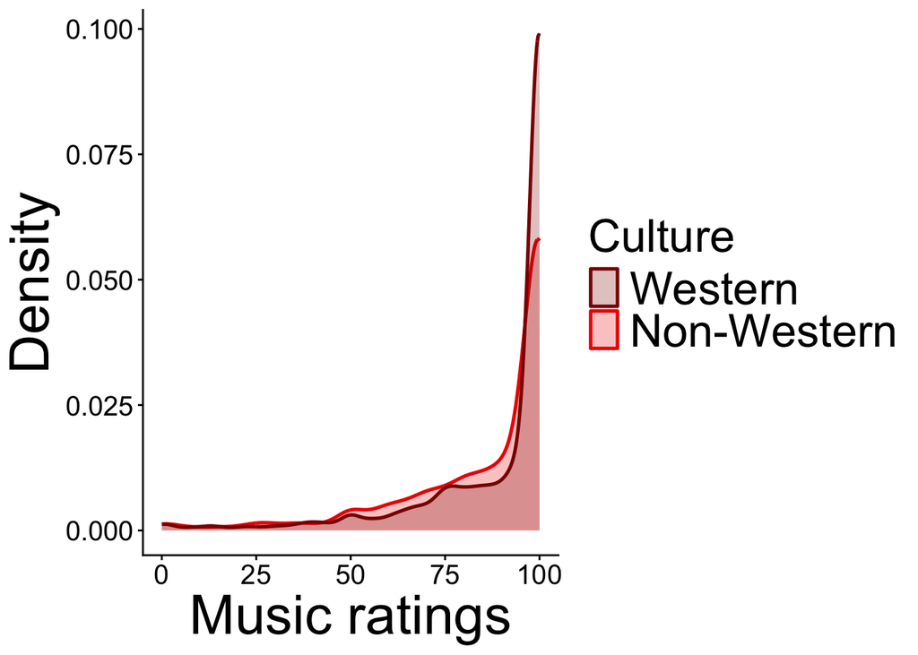

```r
ggplot(ratings_music, aes(x = monra, fill = culture, color = culture)) +
  geom_density(alpha = 0.25, adjust = 1.1, linewidth = 0.9) +
  scale_fill_manual(
    values = c("western" = "red4", "non-western" = "red2"),
    name = "Culture",
    breaks = c("western", "non-western"),
    labels = c("Western", "Non-Western")
  ) +
  scale_color_manual(
    values = c("western" = "red4", "non-western" = "red2"),
    name = "Culture",
    breaks = c("western", "non-western"),
    labels = c("Western", "Non-Western")
  ) +
  labs(x = "Music ratings", y = "Density") +
  theme_classic() +
  theme(
    axis.title = element_text(size = 30),
    axis.text = element_text(size = 15),
    legend.title = element_text(size = 25),
    legend.text = element_text(size = 25)
  )
```

Linear Mixed Effects Model to predict MoNRa by perceptual features (reported)

```r
ratings$audio_name <- as.factor(ratings$audio_name)
ratings$label <- factor(ratings$label, levels = c("non-music", "ambiguous", "music"))
ratings_long$label <- factor(ratings_long$label, levels = c("non-music", "ambiguous", "music"))
ratings_long$variable <- factor(ratings_long$variable, levels = c("monra", "timbre", "tempo", "pulse", "repetition", "harmony", "rhythm", "melody", "complexity", "instrumental", "intentionality"))

null_model <- lmer(monra ~ 1 + (1 | exp_subject_id) + (1 | audio_name), data = ratings)

perceptual_model <- lmer(monra ~ intentionality + instrumental + complexity + repetition + melody + harmony + rhythm + timbre + tempo + pulse + (1 | exp_subject_id) + (1 | audio_name), data = ratings)

summary(perceptual_model)
```

```
## Linear mixed model fit by REML. t-tests use Satterthwaite's method [
## lmerModLmerTest]
## Formula: monra ~ intentionality + instrumental + complexity + repetition +
##     melody + harmony + rhythm + timbre + tempo + pulse + (1 |
##     exp_subject_id) + (1 | audio_name)
##    Data: ratings
##
## REML criterion at convergence: 78916.6
##
## Scaled residuals:
##     Min      1Q  Median      3Q     Max
## -4.6528 -0.5055 -0.0350  0.4966  5.3092
##
## Random effects:
##  Groups         Name        Variance Std.Dev.
##  exp_subject_id (Intercept)  64.74    8.046
##  audio_name     (Intercept) 537.94   23.193
##  Residual                   413.00   20.322
## Number of obs: 8820, groups:  exp_subject_id, 98; audio_name, 90
##
## Fixed effects:
##                   Estimate  Std. Error          df t value             Pr(>|t|)
## (Intercept)      33.675909    2.728372  129.014453  12.343 < 0.0000000000000002
## intentionality    0.077217    0.009956 8728.909204   7.756  0.00000000000000978
## instrumental      0.151672    0.010702 8774.740493  14.172 < 0.0000000000000002
## complexity       -0.004226    0.010116 8738.638677  -0.418              0.67610
## repetition       -0.029779    0.009532 8675.616919  -3.124              0.00179
## melody            0.128546    0.012022 8736.309123  10.693 < 0.0000000000000002
## harmony           0.016332    0.011389 8716.871735   1.434              0.15161
## rhythm            0.047336    0.011097 8726.309988   4.266  0.00002014686979059
## timbre           -0.011034    0.010426 8745.849160  -1.058              0.28996
## tempo            -0.005263    0.011168 8752.661093  -0.471              0.63747
## pulse            -0.008743    0.009762 8706.915368  -0.896              0.37043
##
## (Intercept)    ***
## intentionality ***
## instrumental   ***
## complexity
## repetition     **
## melody         ***
```

[output cut: 16 more lines]

```
## rhythm      -0.022 -0.093 -0.055 -0.016 -0.173 -0.086 -0.181
## timbre      -0.093 -0.002 -0.040  0.022 -0.098 -0.145 -0.106 -0.067
## tempo       -0.100 -0.015  0.007 -0.123 -0.197  0.007 -0.001 -0.064 -0.142
## pulse       -0.005 -0.090 -0.028 -0.036 -0.116 -0.079 -0.068 -0.302  0.021
##             tempo
## intentinlty
## instrumentl
## complexity
## repetition
## melody
## harmony
## rhythm
## timbre
## tempo
## pulse       -0.045
```

```r
r.squaredGLMM(perceptual_model)
```

```
##            R2m       R2c
## [1,] 0.1574188 0.6573847
```

```r
car::vif(perceptual_model)
```

```
## intentionality   instrumental     complexity     repetition         melody
##       1.479496       1.464086       1.217873       1.184791       1.679045
##        harmony         rhythm         timbre          tempo          pulse
##       1.646926       1.583232       1.190989       1.156568       1.385800
```

```r
rand(perceptual_model)
```

|  | npar | logLik | AIC | LRT | Df | Pr(>Chisq) |
| --- | --- | --- | --- | --- | --- | --- |
|  | 14 | -39458.28 | 78944.55 | NA | NA | NA |
| (1 \| exp_subject_id) | 13 | -39945.11 | 79916.22 | 973.6732 | 1 | 0.000000000000000000000000000000000000000000000000000000000000000000000000000000000000000000000000000000000000000000000000000000000000000000000000000000000000000000000000000000000000000000000000000000… |
| (1 \| audio_name) | 13 | -40756.78 | 81539.57 | 2597.0154 | 1 | 0.000000000000000000000000000000000000000000000000000000000000000000000000000000000000000000000000000000000000000000000000000000000000000000000000000000000000000000000000000000000000000000000000000000… |

```r
performance::icc(perceptual_model, by_group = TRUE)
```

| Group | ICC |
| --- | --- |
| exp_subject_id | 0.06374337 |
| audio_name | 0.52963080 |

```r
anova(null_model, perceptual_model)
```

```
## refitting model(s) with ML (instead of REML)
```

|  | npar | AIC | BIC | logLik | -2*log(L) | Chisq | Df | Pr(>Chisq) |
| --- | --- | --- | --- | --- | --- | --- | --- | --- |
| null_model | 4 | 79956.40 | 79984.74 | -39974.20 | 79948.40 | NA | NA | NA |
| perceptual_model | 14 | 78874.55 | 78973.73 | -39423.27 | 78846.55 | 1101.852 | 10 | 0.000000000000000000000000000000000000000000000000000000000000000000000000000000000000000000000000000000000000000000000000000000000000000000000000000000000000000000000000000000000000000000000000000000… |

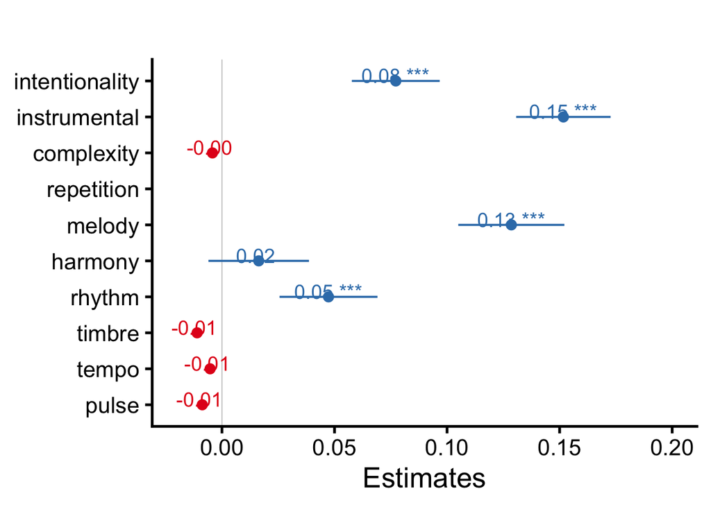

```r
sjPlot::plot_model(perceptual_model, show.values=TRUE, show.p=TRUE, #type = "std",
                   vline.color = "gray", value.size = 5) +
  ylim(-0.02,0.2) +
  theme_classic(base_size = 20) +
  theme(axis.title.x = element_text(size = 20)) +
  labs(
    title = " "
  )
```

Acoustic Feature Selection

Comparing acoustic vs. perceptual features in predicting a music category

Packages

```r
library(factoextra)
library(cowplot)
library(ggfortify)
library(readxl)
library(stats)
library(lme4)
library(lmerTest)
#install.packages("broom.mixed")
library(broom.mixed)
library(factoextra)
library(writexl)
library(ordinal)
library(rcompanion)
library(ordinal)
library(tidyverse)
```

Get and prepare data:

```r
options(scipen=999)

#The features have been extracted already, we read in the data
acoustics_mir<- read_excel("essentia_acoustics_2.xlsx",
    sheet = "Sheet1")
# We clean the names

acoustics_mir$audio_name <- sub("\\.mp3.*", ".mp3", acoustics_mir$audio_name)

# Get the column names
col_names <- colnames(acoustics_mir)
#col_names

# Remove "" from the end of each column name
clean_col_names <- gsub('""$', '', col_names)

# Assign the cleaned column names back to the dataframe
colnames(acoustics_mir) <- clean_col_names

# Check the cleaned column names
#print(colnames(acoustics_mir))

acoustics_mir <- acoustics_mir %>%
  left_join(audio_descriptives %>%
              dplyr::select(audio_name, label, mean_monra),
            by = "audio_name") %>%
  dplyr::select(audio_name, label, mean_monra, everything())


acoustics_mir <- acoustics_mir %>%
  dplyr::select(!id) %>%
  dplyr::select(!average_loudness.value)

acoustics_mir <- acoustics_mir %>% dplyr::select(, 1:251)
```

Scale data:

```r
scaled_mir_ <- acoustics_mir |>
  dplyr::select(!mean_monra) |>
  mutate_if(is.numeric,scale)

# Scale columns 4 to 251
scaled_columns <- scale(acoustics_mir[, 4:251])

# Combine the unscaled first three columns with the scaled columns
acoustics_mir_scaled <- cbind(acoustics_mir[, 1:3], as.data.frame(scaled_columns))
```

Carrying out a PCA on the original acoustic feature set with 248 features

```r
acoustics_mir_scaled_clean <- acoustics_mir_scaled

acoustics_mir_scaled_clean <- acoustics_mir_scaled_clean |>
  mutate(order = ifelse(label == "non-music", 1,
                 ifelse(label == "ambiguous", 2,
                 ifelse(label == "music", 3, NA))))

acoustics_mir_scaled_clean$order <- as.factor(acoustics_mir_scaled_clean$order)

acoustics_mir_scaled_clean <- acoustics_mir_scaled_clean |>
  dplyr::relocate(order, .after = "label")

new_pca_result <- acoustics_mir_scaled_clean |>
  dplyr::select(5:ncol(acoustics_mir_scaled_clean)) |>
  prcomp(center = FALSE, scale. = FALSE)  # already scaled, so no need to rescale

acoustics_mir_scaled_clean <- acoustics_mir_scaled_clean |>
  dplyr::bind_cols(as.data.frame(new_pca_result$x[, 1:3]))

names(acoustics_mir_scaled_clean)
```

```
##   [1] "audio_name"
##   [2] "label"
##   [3] "order"
##   [4] "mean_monra"
##   [5] "barkbands_kurtosis.dmean"
##   [6] "barkbands_kurtosis.dvar"
##   [7] "barkbands_skewness.dmean"
##   [8] "barkbands_skewness.dvar"
##   [9] "barkbands_spread.dmean"
##  [10] "barkbands_spread.dvar"
##  [11] "dissonance.dmean"
##  [12] "dissonance.dvar"
##  [13] "hfc.dmean"
##  [14] "hfc.dvar"
##  [15] "pitch.dmean"
```

[output cut: 240 more lines]

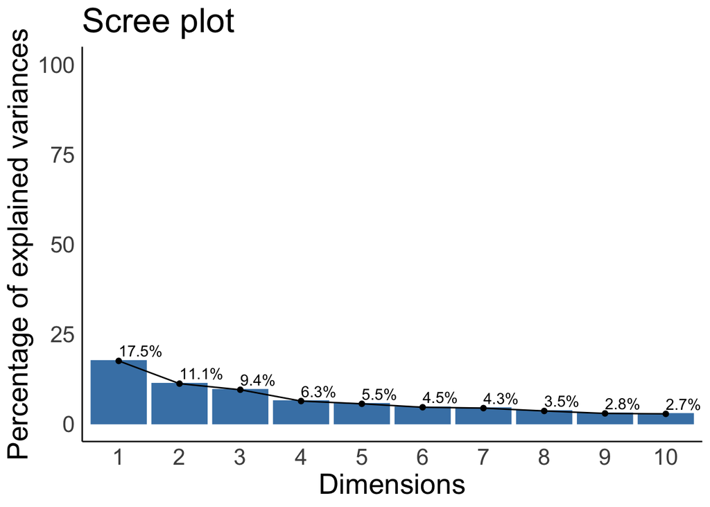

```r
fviz_eig(new_pca_result, addlabels = TRUE, ylim = c(0, 100)) +
  theme_minimal() +  # Minimal theme for a clean look
  theme(
    panel.grid.major = element_blank(),    # Remove major grid lines
    panel.grid.minor = element_blank(),    # Remove minor grid lines
    panel.background = element_blank(),    # Remove background color
    axis.line = element_line(colour = "black"),  # Add axis lines
    legend.position = "NONE",             # Remove the legend
    text = element_text(size = 20))
```

Loadings for acoustic features

```r
# Loadings matrix: rows = features, columns = PCs
loadings <- new_pca_result$rotation

# Top 10 features for PC1 (by absolute loading)
pc1_top <- data.frame(
  feature = rownames(loadings),
  loading = loadings[, "PC1"]
) |>
  dplyr::arrange(dplyr::desc(abs(loading))) |>
  head(10)

# Top 10 features for PC2
pc2_top <- data.frame(
  feature = rownames(loadings),
  loading = loadings[, "PC2"]
) |>
  dplyr::arrange(dplyr::desc(abs(loading))) |>
  head(10)

cat("Top 10 features loading on PC1:\n")
```

```
## Top 10 features loading on PC1:
```

```r
print(pc1_top, row.names = FALSE)
```

```
##                    feature    loading
##              gfcc.dmean_04 -0.1276762
##              gfcc.dmean_02 -0.1266683
##              gfcc.dmean_03 -0.1253903
##  spectral_flatness_db.dvar -0.1250695
##              mfcc.dmean_04 -0.1225416
##               mfcc.dvar_05 -0.1212929
##              gfcc.dmean_05 -0.1193820
##               gfcc.dvar_07 -0.1192079
##              mfcc.dmean_05 -0.1184858
##               mfcc.dvar_04 -0.1175582
```

```r
cat("\nTop 10 features loading on PC2:\n")
```

```
##
## Top 10 features loading on PC2:
```

```r
print(pc2_top, row.names = FALSE)
```

```
##                        feature   loading
##         spectral_entropy.dmean 0.1781026
##            spectral_flux.dmean 0.1777052
##          spectral_spread.dmean 0.1707961
##          spectral_energy.dmean 0.1704956
##           spectral_spread.dvar 0.1684143
##        spectral_kurtosis.dmean 0.1587370
##          spectral_rolloff.dvar 0.1557763
##                  gfcc.dmean_01 0.1548199
##  spectral_energyband_low.dmean 0.1543105
##          barkbands_spread.dvar 0.1531549
```

PCA WITH PERCEPTUAL FEATURES

```r
perceptual_features <- c("mean_pulse","mean_rhythm","mean_repetition","mean_melody",
                         "mean_instrumental","mean_timbre","mean_tempo",
                         "mean_intentionality","mean_harmony","mean_complexity")
pca_result_perceptual <- prcomp(audio_descriptives[, perceptual_features],
                                center = TRUE, scale. = TRUE)

eig.val_per <- get_eigenvalue(pca_result_perceptual)
#eig.val_per

# number of PCs to keep
pcdims_per = 10

# Print eigenvalues
eig.val_per[c(1:pcdims_per),]
```

|  | eigenvalue | variance.percent | cumulative.variance.percent |
| --- | --- | --- | --- |
| Dim.1 | 7.114030878 | 71.14030878 | 71.14031 |
| Dim.2 | 1.537671270 | 15.37671270 | 86.51702 |
| Dim.3 | 0.531176917 | 5.31176917 | 91.82879 |
| Dim.4 | 0.515973932 | 5.15973932 | 96.98853 |
| Dim.5 | 0.120853588 | 1.20853588 | 98.19707 |
| Dim.6 | 0.101245318 | 1.01245318 | 99.20952 |
| Dim.7 | 0.031961880 | 0.31961880 | 99.52914 |
| Dim.8 | 0.027163233 | 0.27163233 | 99.80077 |
| Dim.9 | 0.011530776 | 0.11530776 | 99.91608 |
| Dim.10 | 0.008392208 | 0.08392208 | 100.00000 |

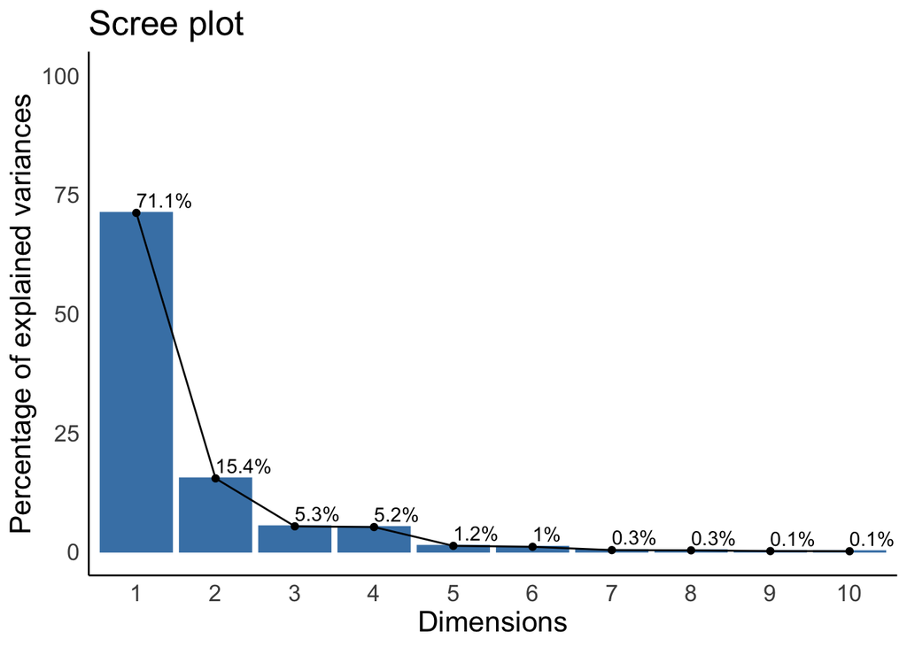

```r
res.feats_per <- get_pca_var(pca_result_perceptual)

contribdf_per  = as.data.frame(res.feats_per$contrib[,c(1:pcdims_per)])
#round(contribdf_per, digits=2)

loadings_per <- pca_result_perceptual$rotation
#loadings_per[,c(1:2)]

res.ind_per <- get_pca_ind(pca_result_perceptual)

pc_scores_per = pca_result_perceptual$x

pca_data_perc <- as.data.frame(pca_result_perceptual$x)
pca_data_perc$label <- acoustics_mir_scaled_clean$label


# Flip PC1 sign for interpretability (high PC1 and PC2 = more music-like).
audio_descriptives$PC1 = pc_scores_per[,1]*-1
audio_descriptives$PC2 = pc_scores_per[,2]*-1

fviz_eig(pca_result_perceptual, addlabels = TRUE, ylim = c(0, 100)) +
  theme_minimal() +  # Minimal theme for a clean look
  theme(
    panel.grid.major = element_blank(),    # Remove major grid lines
    panel.grid.minor = element_blank(),    # Remove minor grid lines
    panel.background = element_blank(),    # Remove background color
    axis.line = element_line(colour = "black"),  # Add axis lines
    legend.position = "NONE",             # Remove the legend
    text = element_text(size = 16))
```

Predicting clusters based on the first 2 PCs of acoustic and perceptual features

```r
clm_df <- audio_descriptives |>
  dplyr::select(audio_name, PC1, PC2, label) |>
  mutate(order = dplyr::case_when(
    label == "music"     ~ 3,
    label == "ambiguous" ~ 2,
    label == "non-music" ~ 1
  ))

clm_df$order <- factor(clm_df$order, levels = c(1, 2, 3), ordered = TRUE)
acoustics_mir_scaled_clean$order <- factor(acoustics_mir_scaled_clean$order, levels = c(1, 2, 3), ordered = TRUE)

clm_ac_new <- clm(order ~ PC1 + PC2, data = acoustics_mir_scaled_clean)
summary(clm_ac_new)
```

```
## formula: order ~ PC1 + PC2
## data:    acoustics_mir_scaled_clean
##
##  link  threshold nobs logLik AIC    niter max.grad cond.H
##  logit flexible  90   -83.77 175.54 5(0)  7.29e-10 1.0e+02
##
## Coefficients:
##     Estimate Std. Error z value Pr(>|z|)
## PC1  0.07940    0.03333   2.382  0.01721 *
## PC2  0.24732    0.07737   3.196  0.00139 **
## ---
## Signif. codes:  0 '***' 0.001 '**' 0.01 '*' 0.05 '.' 0.1 ' ' 1
##
## Threshold coefficients:
##     Estimate Std. Error z value
## 1|2  -0.7135     0.2627  -2.716
## 2|3   0.2864     0.2547   1.124
```

```r
clm_perceptual <- clm(order ~ PC1 + PC2, data = clm_df)
summary(clm_perceptual)
```

```
## formula: order ~ PC1 + PC2
## data:    clm_df
##
##  link  threshold nobs logLik AIC   niter max.grad cond.H
##  logit flexible  90   -11.02 30.04 10(0) 1.09e-11 2.2e+02
##
## Coefficients:
##     Estimate Std. Error z value Pr(>|z|)
## PC1    6.271      2.330   2.692  0.00711 **
## PC2    2.755      1.092   2.524  0.01162 *
## ---
## Signif. codes:  0 '***' 0.001 '**' 0.01 '*' 0.05 '.' 0.1 ' ' 1
##
## Threshold coefficients:
##     Estimate Std. Error z value
## 1|2   -7.007      2.439  -2.873
## 2|3    6.879      2.640   2.606
```

```r
clm_order_null <- clm(order ~ 1, data = clm_df)

anova(clm_ac_new, clm_order_null)
```

|  | no.par | AIC | logLik | LR.stat | df | Pr(>Chisq) |
| --- | --- | --- | --- | --- | --- | --- |
| clm_order_null | 2 | 193.8856 | -94.94282 | NA | NA | NA |
| clm_ac_new | 4 | 175.5430 | -83.77150 | 22.34264 | 2 | 0.00001407205 |

```r
anova(clm_perceptual, clm_order_null)
```

|  | no.par | AIC | logLik | LR.stat | df | Pr(>Chisq) |
| --- | --- | --- | --- | --- | --- | --- |
| clm_order_null | 2 | 193.88563 | -94.94282 | NA | NA | NA |
| clm_perceptual | 4 | 30.04371 | -11.02185 | 167.8419 | 2 | 0.0000000000000000000000000000000000003577581 |

```r
###Pseudo r sqaured
nagelkerke(clm_ac_new, clm_order_null)
```

```
## $Models
##
## Model: "clm, order ~ PC1 + PC2, acoustics_mir_scaled_clean"
## Null:  "clm, order ~ 1, clm_df"
##
## $Pseudo.R.squared.for.model.vs.null
##                              Pseudo.R.squared
## McFadden                             0.117664
## Cox and Snell (ML)                   0.219836
## Nagelkerke (Cragg and Uhler)         0.250171
##
## $Likelihood.ratio.test
##  Df.diff LogLik.diff  Chisq     p.value
##       -2     -11.171 22.343 0.000014072
##
## $Number.of.observations
##
## Model: 90
## Null:  90
##
## $Messages
## [1] "Note: For models fit with REML, these statistics are based on refitting with ML"
##
## $Warnings
## [1] "None"
```

```r
nagelkerke(clm_perceptual, clm_order_null)
```

```
## $Models
##
## Model: "clm, order ~ PC1 + PC2, clm_df"
## Null:  "clm, order ~ 1, clm_df"
##
## $Pseudo.R.squared.for.model.vs.null
##                              Pseudo.R.squared
## McFadden                             0.883911
## Cox and Snell (ML)                   0.845090
## Nagelkerke (Cragg and Uhler)         0.961703
##
## $Likelihood.ratio.test
##  Df.diff LogLik.diff  Chisq                                     p.value
##       -2     -83.921 167.84 0.00000000000000000000000000000000000035776
##
## $Number.of.observations
##
## Model: 90
## Null:  90
##
## $Messages
## [1] "Note: For models fit with REML, these statistics are based on refitting with ML"
##
## $Warnings
## [1] "None"
```

```r
  # Compare AIC
AIC(clm_perceptual, clm_ac_new)
```

|  | df | AIC |
| --- | --- | --- |
| clm_perceptual | 4 | 30.04371 |
| clm_ac_new | 4 | 175.54299 |

```r
# Compare BIC
BIC(clm_perceptual, clm_ac_new)
```

|  | df | BIC |
| --- | --- | --- |
| clm_perceptual | 4 | 40.04295 |
| clm_ac_new | 4 | 185.54223 |

Eigenvalues of PCs

```r
# Eigenvalues = sdev^2
eig_new        <- new_pca_result$sdev^2
eig_perceptual <- pca_result_perceptual$sdev^2

# How many components have eigenvalue > 1?
cat("new_pca_result: ", sum(eig_new > 1), "PCs with eigenvalue > 1\n")
```

```
## new_pca_result:  33 PCs with eigenvalue > 1
```

```r
cat("pca_result_perceptual: ", sum(eig_perceptual > 1), "PCs with eigenvalue > 1\n")
```

```
## pca_result_perceptual:  2 PCs with eigenvalue > 1
```

```r
# See the actual values for the first several PCs
head(eig_new, 10)
```

```
##  [1] 43.306934 27.604494 23.381307 15.556977 13.676900 11.277483 10.695153
##  [8]  8.717035  7.026406  6.712983
```

```r
head(eig_perceptual, 10)
```

```
##  [1] 7.114030878 1.537671270 0.531176917 0.515973932 0.120853588 0.101245318
##  [7] 0.031961880 0.027163233 0.011530776 0.008392208
```

```r
sum(eig_new > 1)
```

```
## [1] 33
```

```r
length(eig_new)
```

```
## [1] 90
```

```r
length(new_pca_result$sdev)   # number of PCs returned
```

```
## [1] 90
```

```r
nrow(acoustics_mir_scaled_clean)  # number of stimuli
```

```
## [1] 90
```

Figure 3a Acoustic and Perceptual Spaces

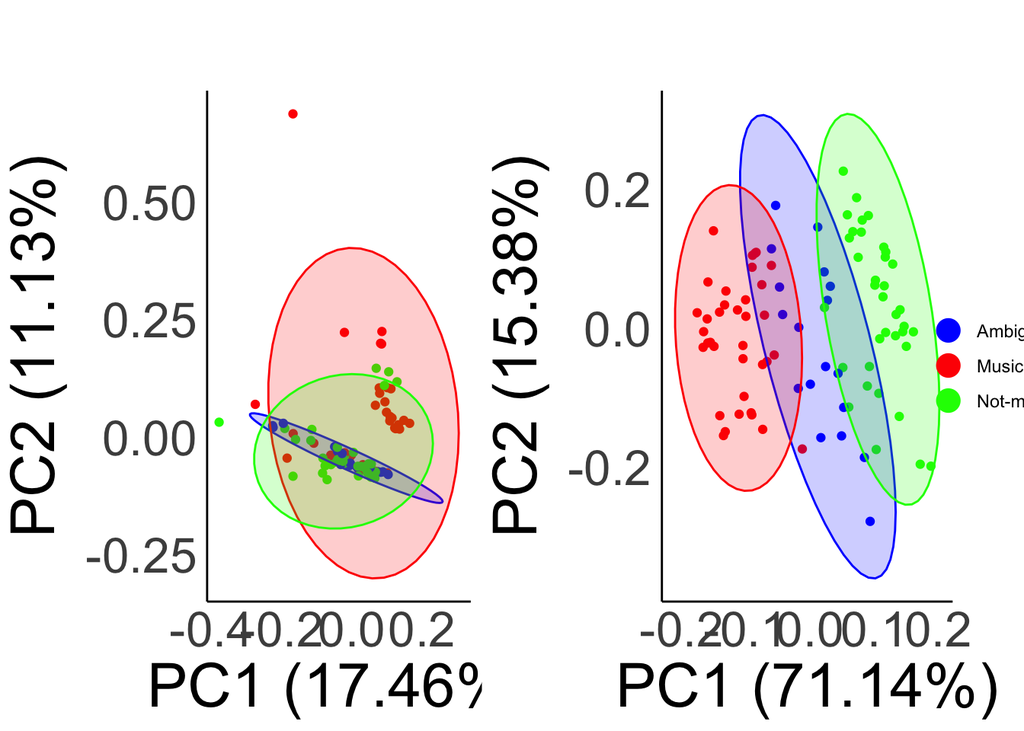

```r
acoustic_pca_plot <- autoplot(new_pca_result,
         data = acoustics_mir_scaled_clean,
         colour = 'label',
         loadings = FALSE,
         loadings.label = FALSE,
         loadings.color = "black",
         loadings.label.color = "black",
         loadings.label.repel = FALSE,
         loadings.label.size = 5,
         frame = TRUE,
         frame.type = 'norm') +
  # Customize appearance
  theme_minimal() +  # Minimal theme for a clean look
  theme(
    panel.grid.major = element_blank(),    # Remove major grid lines
    panel.grid.minor = element_blank(),    # Remove minor grid lines
    panel.background = element_blank(),    # Remove background color
    axis.line = element_line(colour = "black"),  # Add axis lines
    legend.position = "NONE",             # Remove the legend
    text = element_text(size = 30)         # Increase text size
  ) +
  scale_color_manual(values = c("music" = "red", "ambiguous" = "blue", "non-music" = "green")) +
   scale_fill_manual(values = c("music" = "red", "ambiguous" = "blue", "non-music" = "green")) + # Custom colors
  labs(
    title = " ",
    colour = "Mean MONRA Rating"           # Label for the legend
  )
perceptual_pca_plot <- autoplot(pca_result_perceptual,
         data = audio_descriptives,
         colour = 'label',
         loadings = FALSE,
         loadings.label = FALSE,
         loadings.color = "black",
         loadings.label.color = "black",
         loadings.label.repel = FALSE,
         loadings.label.size = 5,
         frame = TRUE,
         frame.type = 'norm') +
  # Customize appearance
  theme_minimal() +  # Minimal theme for a clean look
  theme(
    panel.grid.major = element_blank(),    # Remove major grid lines
    panel.grid.minor = element_blank(),    # Remove minor grid lines
    panel.background = element_blank(),    # Remove background color
    axis.line = element_line(colour = "black"),  # Add axis lines
    legend.position = "NONE",             # Remove the legend
    text = element_text(size = 30)         # Increase text size
  ) +
  scale_color_manual(values = c("music" = "red", "ambiguous" = "blue", "non-music" = "green")) +
   scale_fill_manual(values = c("music" = "red", "ambiguous" = "blue", "non-music" = "green")) + # Custom colors
  labs(
    title = " ",
    colour = "Mean MONRA Rating"           # Label for the legend
  )

legend_pca <- ggplot(data = audio_descriptives, aes(x = 1, y = 1, colour = label)) +
  geom_point() +
  scale_color_manual(values = c("music" = "red", "ambiguous" = "blue", "non-music" = "green"),
                     labels = c("Ambiguous", "Music", "Not-music")) +
  theme_void() +
  theme(legend.position = "right") +
  guides(colour = guide_legend(override.aes = list(size = 5))) +
  labs(colour = NULL)  # Remove the legend title


loadings_labels <- rownames(pca_result_perceptual$rotation)

# Remove "mean_" from the loadings labels and capitalize the first letter
loadings_labels <- gsub("^mean_", "", loadings_labels)  # Remove "mean_"
loadings_labels <- tools::toTitleCase(loadings_labels)  # Capitalize first letter

# Reassign the modified labels back to the PCA object
rownames(pca_result_perceptual$rotation) <- loadings_labels

cowplot::plot_grid(acoustic_pca_plot, perceptual_pca_plot, legend_pca, ncol = 3, rel_widths = c(0.8, 0.8, 0.1))
```

Boxplots of mean feature ratings across clusters (Figure 3B)

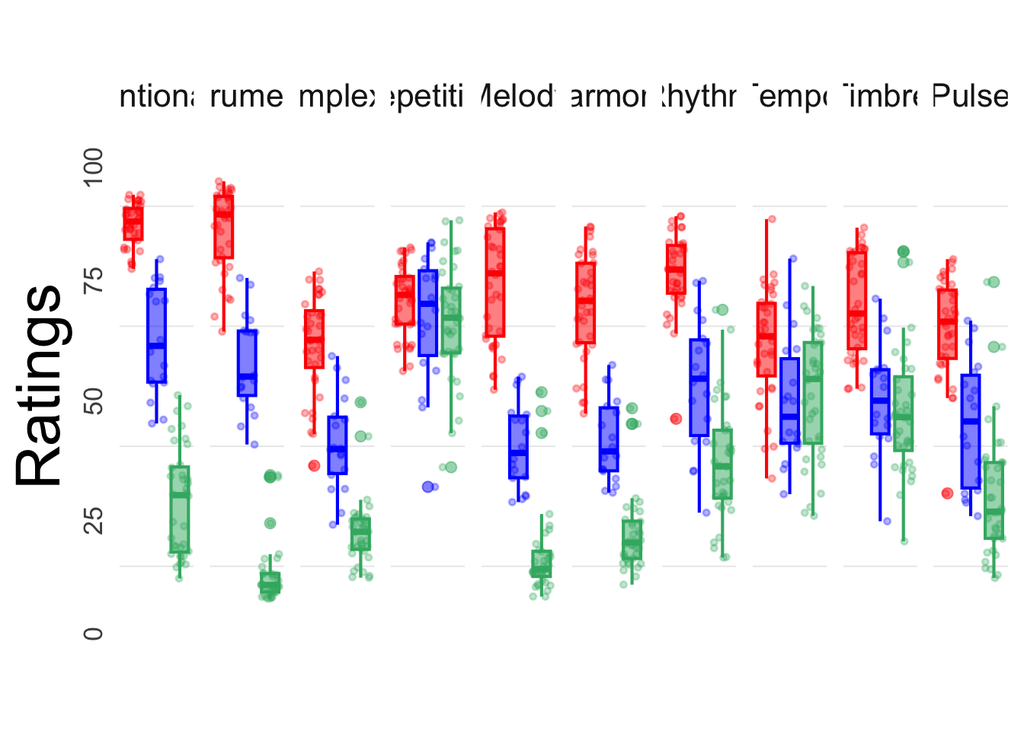

```r
audio_features <- dplyr::select(audio_descriptives, audio_name, mean_monra, mean_pulse, mean_rhythm, mean_repetition, mean_melody, mean_instrumental, mean_timbre, mean_tempo, mean_intentionality, mean_harmony, mean_complexity, label)

library(writexl)
write_xlsx(audio_features, "audio_features.xlsx")

audio_features_long <- pivot_longer(audio_features,
                                  cols = c(mean_pulse, mean_rhythm, mean_repetition, mean_melody, mean_instrumental,
                                                 mean_timbre, mean_tempo, mean_intentionality, mean_harmony, mean_complexity),
                                  names_to = "variable",
                                  values_to = "value")

audio_features_long$variable <- as.factor(audio_features_long$variable)
audio_features_long$label <- factor(audio_features_long$label, levels = c("music", "ambiguous", "non-music"))


 # Modify the 'variable' column: Remove "mean_" and capitalize the first letter
audio_features_long <- audio_features_long %>%
  mutate(variable = gsub("^mean_", "", variable),      # Remove "mean_"
         variable = tools::toTitleCase(variable))     # Capitalize first letter

audio_features_long$variable <- factor(audio_features_long$variable,
                                      levels = c("Intentionality", "Instrumental", "Complexity", "Repetition", "Melody", "Harmony", "Rhythm", "Tempo", "Timbre", "Pulse"))


 ratings_cluster_plot_mean <- ggplot(audio_features_long, aes(x = label, y = value, color = label, fill = label)) +
  geom_boxplot(alpha = 0.5, position = position_dodge(width = 0.75)) +
   geom_jitter(alpha = 0.3, size = 1) +
  theme_minimal(base_size = 16) +  # Increase base font size
  theme(
    axis.title = element_text(size = 30),
    plot.title = element_text(size = 18, face = "bold"),
    legend.position = "none",  # Hide legend
    strip.text = element_text(size = 16),  # Facet label text
    panel.grid.major = element_blank(),  # Remove major grid lines
    axis.text.x = element_blank(),
    axis.text.y = element_text(angle = 90, vjust = 0.5, hjust = 1), # Rotate x-axis text
    axis.title.y = element_text(size = 30)
  ) +
   ylim(0,100) +
  labs(
    title = " ",
    x = " ",
    y = "Ratings"
  ) +
  facet_grid(~variable, scales = "free_x", space = "free")  +
  scale_color_manual(values = c("music" = "red", "ambiguous" = "blue", "non-music" = "#3CB371")) +
  scale_fill_manual(values = c("music" = "red", "ambiguous" = "blue", "non-music" = "#3CB371"))


ratings_cluster_plot_mean
```

Radar Chart of mean feature ratings for different clusters (Figure 3C)

```r
audio_descriptives_wo_monra <- audio_descriptives %>%
  dplyr::select(cluster, label, mean_repetition, mean_timbre, mean_tempo, mean_pulse, mean_harmony, mean_melody, mean_rhythm, mean_complexity, mean_intentionality, mean_instrumental)

subgroup_summary_pag <- audio_descriptives_wo_monra %>%
  group_by(label) %>%
  summarise(across(starts_with("mean"), list(mean = mean), .names = "{.col}_{.fn}")) %>%
  rename(mean_pulse = mean_pulse_mean,
         mean_rhythm = mean_rhythm_mean,
         mean_timbre = mean_timbre_mean,
         mean_repetition = mean_repetition_mean,
         mean_tempo = mean_tempo_mean,
         mean_melody = mean_melody_mean,
         mean_harmony = mean_harmony_mean,
         mean_intentionality = mean_intentionality_mean,
         mean_instrumental = mean_instrumental_mean,
         mean_complexity = mean_complexity_mean)


# Prepare the data by adding max and min rows
max_values <- rep(100, ncol(subgroup_summary_pag) - 1)
min_values <- rep(0, ncol(subgroup_summary_pag) - 1)
data_for_radar <- rbind(max_values, min_values, subgroup_summary_pag[, -1])

# Add row names for clarity (optional)
rownames(data_for_radar) <- c("Max", "Min", paste(subgroup_summary_pag$label))
```

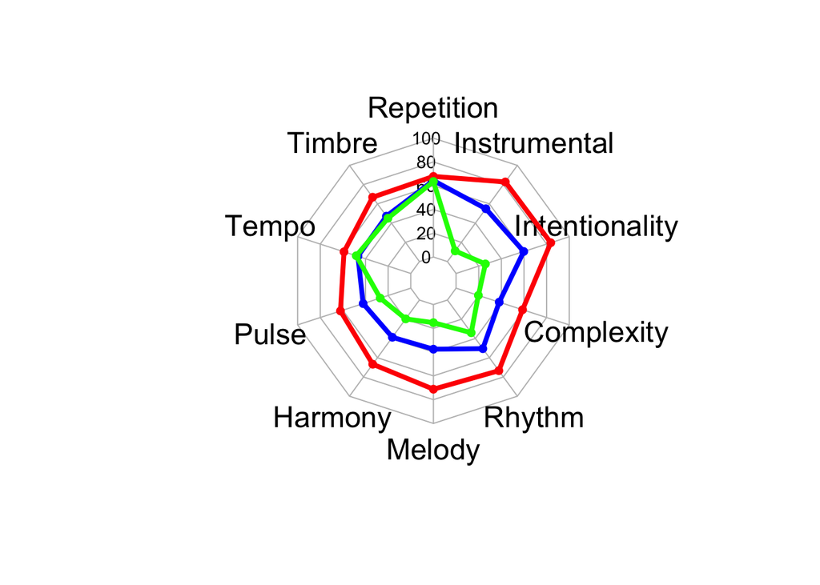

```r
data_for_radar <- data_for_radar %>%
  rename(Repetition = mean_repetition,
         Timbre = mean_timbre,
         Instrumental = mean_instrumental,
         Intentionality = mean_intentionality,
         Complexity = mean_complexity,
         Melody = mean_melody,
         Harmony = mean_harmony,
         Rhythm = mean_rhythm,
         Pulse = mean_pulse,
         Tempo = mean_tempo)



# Create the radar chart
radarchart(data_for_radar,
           axistype = 1,
           # Customize the appearance
           pcol = c("blue", "red", "green"),  # Colors for each cluster (nonmusic, ambiguous, music)
           plwd = 4,  # Line width
           plty = 1,  # Line type
           cglcol = "grey",  # Color of the grid lines
           cglty = 1,  # Type of the grid lines
           axislabcol = "black",  # Color of the axis labels
           caxislabels = seq(0, 100, by = 20),  # Axis labels from 0 to 100
           vlcex = 1.5,  # Variable label size
           calcex = 0.9,  # Axis label size
           maxmin = TRUE,  # Ensure max and min values are used
           seg = 5  # Force 5 segments (0, 20, 40, 60, 80, 100)
)
```